# Import Required Libraries

Import NumPy, SciPy, and Matplotlib for working with Poisson distributions.

```python
import numpy as np
import scipy.stats as stats
import matplotlib.pyplot as plt
from IPython.display import Markdown, display
```

# Understanding Poisson Distribution

The Poisson distribution is a discrete probability distribution that expresses the probability of a given number of events occurring in a fixed interval of time or space if these events occur with a known constant mean rate and independently of the time since the last event. It has one parameter: λ (lambda), which is the average number of events per interval.

```python
# Generate Poisson Random Variables
lambda_param = 3  # Average number of events
poisson_rvs = np.random.poisson(lambda_param, size=1000)
print("Sample Poisson random variables:", poisson_rvs[:10])
```

```
Sample Poisson random variables: [6 2 2 2 2 1 2 4 4 3]
```

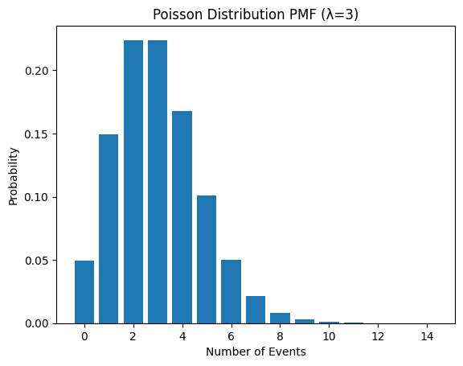

```python
# Plot Poisson Distribution
x = np.arange(0, 15)
pmf = stats.poisson.pmf(x, lambda_param)
plt.bar(x, pmf)
plt.xlabel('Number of Events')
plt.ylabel('Probability')
plt.title('Poisson Distribution PMF (λ=3)')
plt.show()
```

```python
# Calculate Poisson Probabilities
k = 5  # Specific number of events
prob = stats.poisson.pmf(k, lambda_param)
print(f"Probability of exactly {k} events: {prob}")

# Cumulative probability
cum_prob = stats.poisson.cdf(k, lambda_param)
print(f"Cumulative probability up to {k} events: {cum_prob}")
```

```
Probability of exactly 5 events: 0.10081881344492458
Cumulative probability up to 5 events: 0.9160820579686965
```

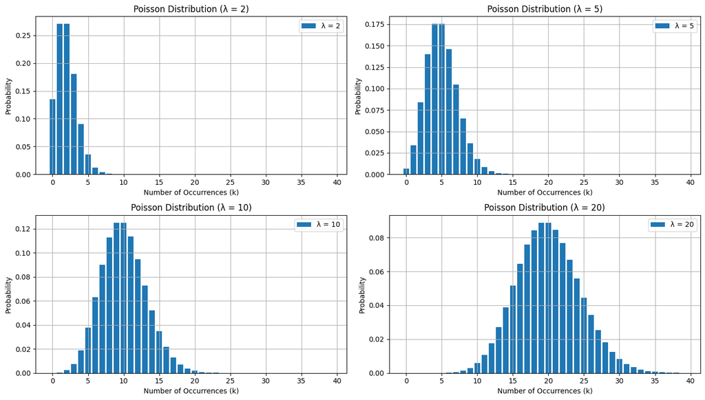

```python
import numpy as np
from scipy.stats import poisson
import matplotlib.pyplot as plt

# Let's define different lambda values
lambda_values = [2, 5, 10, 20]

# A range for the possible number of events (k)
k_values = np.arange(0, 40)

# Graph settings
plt.figure(figsize=(14, 8))

# Let's plot the distribution for each lambda value
for i, lam in enumerate(lambda_values):
    # Calculate the Probability Mass Function (PMF)
    probabilities = poisson.pmf(k_values, lam)

    ax = plt.subplot(2, 2, i + 1)
    ax.bar(k_values, probabilities, label=f'λ = {lam}')
    ax.set_title(f'Poisson Distribution (λ = {lam})')
    ax.set_xlabel('Number of Occurrences (k)')
    ax.set_ylabel('Probability')
    ax.legend()
    ax.grid(True)

plt.tight_layout()
plt.show()
```

Poisson Regression: Making Sense of Count Data

Poisson Regression is a specialized regression analysis technique used when the dependent variable is count data. This type of data represents the number of times an event occurs within a specific time interval or space, and it consists of non-negative integers (0, 1, 2, 3,...).

Why Is It Different from Linear Regression? The first question that might come to mind is, "Why not just use a standard Linear Regression for this type of data?" Here are the fundamental reasons:

Distribution Assumption: Linear regression assumes that the errors (residuals) are normally distributed. However, count data often follows a Poisson distribution or similar skewed distributions. Using linear regression for discrete, Poisson-distributed data can lead to inefficient, inconsistent, and contradictory results.

Negative Predictions: A linear regression model can produce negative predictions. However, the count of an event cannot be negative (e.g., -2 accidents). Poisson regression uses a logarithmic link function to ensure that the predictions are always positive.

Constant Variance: Linear regression assumes that the variance is constant (homoscedasticity). In a Poisson distribution, however, the variance is equal to the mean. This means that as the average number of events increases, the variance also increases, which contradicts the assumption of linear regression.

When to Use Poisson Regression?

Poisson regression is ideal for modeling scenarios such as:

Medicine/Biostatistics: The number of seizures a patient experiences in a month while on a specific treatment.

Marketing: Predicting the number of times a customer will purchase a particular product in a year.

Transportation: Modeling the number of accidents at a specific intersection based on factors like traffic volume and weather conditions.

Finance: Estimating the number of fraudulent cases a bank encounters on a monthly basis.

Agriculture: Analyzing the factors that affect the number of pests on a plant.

Key Assumptions:

For a Poisson regression model to yield accurate results, several key assumptions must be met:

Distribution of the Dependent Variable: The dependent variable (the count data we are trying to predict) must follow a Poisson distribution.

Equality of Mean and Variance: The conditional mean of the data must be equal to its conditional variance. This is a fundamental property of the Poisson distribution.

Independence: The observations must be independent of each other.

Log-Linearity: It is assumed that there is a linear relationship between the independent variables and the logarithm of the dependent variable.

Interpreting the Model

In linear regression, the coefficients represent the additive effect on the dependent variable for a one-unit change in the independent variable. In Poisson regression, the coefficients represent the effect on the logarithm of the dependent variable for a one-unit change in the independent variable.

In practice, this means we interpret the coefficients by taking their exponential (e^β). This value represents the multiplicative factor by which the expected count changes when the independent variable increases by one unit.

The Problem of Overdispersion

In real-world applications, the variance of count data is often larger than its mean. This situation is called overdispersion. Overdispersion violates the assumptions of the Poisson regression model and can lead to incorrect conclusions. In such cases, more flexible models that are extensions of the Poisson model, such as Negative Binomial Regression, are preferred.

In summary, when we identify that our dependent variable is count data and observe that its mean and variance are close to each other, using Poisson regression instead of standard linear regression allows our model to make more accurate predictions and is more appropriate for the nature of the data. This directly improves model performance.

So How to find proper poisson function for a variable ? how one can prove that "hey this variable has a significant poisson distribution" ?

This is a critical step in the modeling process. You can't just assume a variable follows a certain distribution; you need to gather evidence to support that assumption.

Here is a step-by-step guide on how to determine the specific Poisson function for your variable and then test if that variable truly follows a Poisson distribution.

Step 1: Finding the "Proper Poisson Function" (Estimating λ)

A Poisson distribution is defined by a single parameter: lambda (λ), which represents the mean (and variance) of the distribution. Therefore, "finding the proper Poisson function" simply means estimating the value of λ from your data.

The best and most common way to estimate λ is to calculate the sample mean of your variable. The sample mean is the Maximum Likelihood Estimator (MLE) for the Poisson parameter.

Formula: λ_estimated = (Σ xᵢ) / n = sample mean of the data

So, if you have a variable representing the number of customer complaints per day, you would simply calculate the average number of complaints per day from your historical data. That average becomes your estimated λ.

Step 2: Proving That the Variable Follows a Poisson Distribution

Once you have your estimated λ, you can test the hypothesis: "Does my data follow a Poisson distribution with this λ?" This is not a single check but a combination of methods.

Here are the most common techniques, from simple heuristics to formal statistical tests:

1. Compare the Mean and Variance

This is the quickest and most important heuristic check.

The core property of a Poisson distribution is that its mean is equal to its variance (μ = σ²).

Action: Calculate the sample mean and the sample variance of your data.

Interpretation:

If variance ≈ mean, you have strong evidence that the data might be Poisson distributed.

If variance > mean, this is a condition known as overdispersion. Your data is more spread out than a Poisson distribution would predict. In this case, a Negative Binomial distribution is often a better fit.

If variance < mean, this is underdispersion, which is less common but can happen.

2. Visual Check: The Histogram

A powerful method is to plot the frequency distribution of your data and compare it to the theoretical Poisson distribution you've estimated.

Action:

Create a histogram or a bar chart showing the frequency of each count in your data (i.e., how many times you observed 0, 1, 2, 3, etc.).

Using your estimated λ, calculate the theoretical probabilities for each count using the Poisson Probability Mass Function (PMF).

Overlay the theoretical distribution on your data's histogram.

Interpretation: If the shape of your data's histogram closely matches the shape of the theoretical Poisson PMF, it's a very good sign.

3. Formal Test: The Chi-Squared Goodness-of-Fit Test

This is a formal statistical test that provides a quantitative measure of how well your data fits the Poisson distribution.

Concept: The test compares the observed frequencies of each count in your data with the expected frequencies that a Poisson distribution (with your estimated λ) would predict.

Hypotheses:

Null Hypothesis (H₀): The data follows a Poisson distribution.

Alternative Hypothesis (H₁): The data does not follow a Poisson distribution.

Interpretation (using the p-value):

If p-value > 0.05 (or your chosen significance level, α), you do not reject the null hypothesis. This means there is no significant evidence to say your data is not from a Poisson distribution. This supports your assumption.

If p-value < 0.05, you reject the null hypothesis. This means there is a statistically significant difference between your data and the theoretical Poisson distribution.

```
Step 1: Estimate Parameters
-----------------------------
Estimated Lambda (Sample Mean): 7.8410

Check 1: Compare Mean and Variance
----------------------------------
Sample Mean:    7.8410
Sample Variance: 6.7525
Result: Mean and Variance are not close. Check for over/underdispersion.

Check 2: Visual Inspection
---------------------------
Generating plot...
```

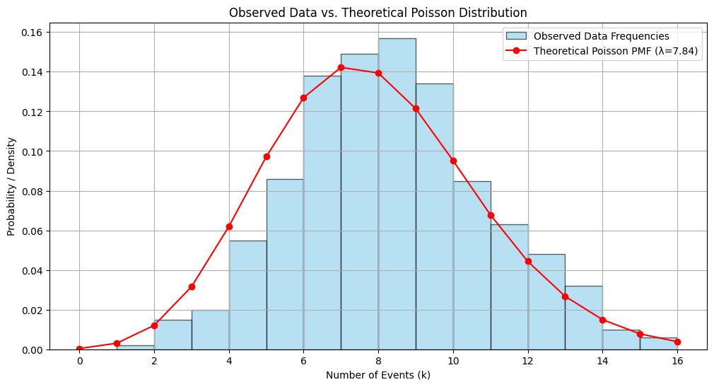

```
Check 3: Chi-Squared Goodness-of-Fit Test
-------------------------------------------
Chi-Squared Statistic: 20.0929
P-value: 0.2161
Result: P-value is greater than 0.05. We do not reject the null hypothesis.
Conclusion: The data is consistent with a Poisson distribution.
```

```python
# Let's create a dataset that IS truly Poisson distributed for our test.
# We'll use lambda = 8 (e.g., average of 8 website visitors per minute)
np.random.seed(42)
true_lambda = 8
data = np.random.poisson(true_lambda, size=1000)


# --- Step 1: Estimate Lambda ---
estimated_lambda = np.mean(data)
print(f"Step 1: Estimate Parameters")
print(f"-----------------------------")
print(f"Estimated Lambda (Sample Mean): {estimated_lambda:.4f}\n")


# --- Step 2: Verify the Distribution ---

# 1. Compare Mean and Variance
sample_variance = np.var(data, ddof=1) # ddof=1 for sample variance
print(f"Check 1: Compare Mean and Variance")
print(f"----------------------------------")
print(f"Sample Mean:    {estimated_lambda:.4f}")
print(f"Sample Variance: {sample_variance:.4f}")
if abs(estimated_lambda - sample_variance) < (estimated_lambda * 0.1): # Check if they are within 10%
    print("Result: Mean and Variance are close. This supports the Poisson assumption.\n")
else:
    print("Result: Mean and Variance are not close. Check for over/underdispersion.\n")


# 2. Visual Check with Histogram
print(f"Check 2: Visual Inspection")
print(f"---------------------------")
print("Generating plot...")
# Get the observed frequencies
observed_counts = np.bincount(data)
observed_freq = observed_counts / len(data)

# Get the theoretical probabilities from the Poisson PMF
k_values = np.arange(0, max(data) + 1)
theoretical_probs = stats.poisson.pmf(k_values, mu=estimated_lambda)

# Plotting
plt.figure(figsize=(12, 6))
plt.hist(data, bins=k_values, density=True, alpha=0.6, label='Observed Data Frequencies', color='skyblue', edgecolor='black')
plt.plot(k_values, theoretical_probs, 'r-o', label=f'Theoretical Poisson PMF (λ={estimated_lambda:.2f})')
plt.title('Observed Data vs. Theoretical Poisson Distribution')
plt.xlabel('Number of Events (k)')
plt.ylabel('Probability / Density')
plt.legend()
plt.grid(True)
plt.show()


# 3. Chi-Squared Goodness-of-Fit Test
print(f"\nCheck 3: Chi-Squared Goodness-of-Fit Test")
print(f"-------------------------------------------")

# The Chi-Squared test works best with binned data.
# We'll use the counts we already calculated.
# The expected frequencies are the theoretical probabilities multiplied by the total number of samples.
expected_counts = theoretical_probs * len(data)

# Normalize expected counts to match observed sum (to handle floating point precision issues)
expected_counts = expected_counts * (observed_counts.sum() / expected_counts.sum())

# Perform the test. We compare the observed counts with the expected counts.
# Note: Some bins might have very low expected counts, which can be an issue.
# For a more robust test, one might group bins with expected counts < 5.
# For this example, we'll proceed.
chi2_stat, p_value = stats.chisquare(f_obs=observed_counts[:len(expected_counts)], f_exp=expected_counts)

print(f"Chi-Squared Statistic: {chi2_stat:.4f}")
print(f"P-value: {p_value:.4f}")

if p_value > 0.05:
    print("Result: P-value is greater than 0.05. We do not reject the null hypothesis.")
    print("Conclusion: The data is consistent with a Poisson distribution.")
else:
    print("Result: P-value is less than 0.05. We reject the null hypothesis.")
    print("Conclusion: The data does not appear to follow a Poisson distribution.")
```

But here is the problem might be mean and variance values never equal because of decimal points ? so what is the acceptance rate between them to accept that the hypothesis that they are equal ?

So, you are right to ask for an "acceptance rate" or a practical threshold. While there is no single, universally agreed-upon magic number, here are the standard methods and rules of thumb used by statisticians and data scientists to decide if the mean and variance are "close enough."

1. The Dispersion Index (The Variance-to-Mean Ratio): The most common and useful metric is the Dispersion Index (also called the dispersion parameter). Dispersion Index = Sample Variance / Sample Mean For a perfect Poisson distribution, the Dispersion Index is exactly 1.0. Dispersion Index > 1.0 indicates Overdispersion. The variance is greater than the mean. Dispersion Index < 1.0 indicates Underdispersion. The variance is less than the mean.

Rules of Thumb for the Dispersion Index: There isn't a strict cutoff, but here is a widely used guideline: 0.8 to 1.2: Generally considered "close enough" to 1.0. If your index falls in this range, you can often proceed with a Poisson model with reasonable confidence. 1.2 to 1.5 (or 0.5 to 0.8): This is a gray area. It suggests some deviation from the Poisson assumption. You should be cautious and might want to compare the performance of a Poisson model with an alternative, like a Negative Binomial model.

> 1.5 (or < 0.5): This is strong evidence that the Poisson assumption is violated. A standard Poisson model will likely produce incorrect standard errors and p-values, leading to flawed conclusions. In the case of overdispersion (>1.5), you should strongly consider using a Negative Binomial Regression model instead.

Important Context: The larger your sample size, the more seriously you should take smaller deviations from 1.0. A dispersion index of 1.1 in a massive dataset might be statistically significant, whereas in a small dataset of 30 points, it's likely just noise.

2. Statistical Tests for Dispersion For a more formal approach, you can perform a statistical test where the null hypothesis is that the mean and variance are equal. A common method is the likelihood-ratio test, which compares the Poisson model (which fixes dispersion at 1) to a more flexible model like the Negative Binomial model (which estimates dispersion as a parameter). If the test shows a statistically significant result (e.g., p-value < 0.05), it provides evidence that the extra dispersion parameter in the Negative Binomial model is necessary, meaning your data is not truly Poisson.

```python
def analyze_dispersion(data, name):
    """Calculates and interprets the dispersion of a dataset."""
    mean = np.mean(data)
    variance = np.var(data, ddof=1) # Use ddof=1 for the sample variance
    dispersion_index = variance / mean

    print(f"--- Analysis for: {name} ---")
    print(f"Sample Mean:    {mean:.3f}")
    print(f"Sample Variance: {variance:.3f}")
    print(f"Dispersion Index (Var/Mean): {dispersion_index:.3f}")

    if 0.8 <= dispersion_index <= 1.2:
        print("Conclusion: Looks consistent with a Poisson distribution.\n")
    elif dispersion_index > 1.2:
        print("Conclusion: Evidence of OVERDISPERSION. A Poisson model may not be appropriate.\n")
    else: # dispersion_index < 0.8
        print("Conclusion: Evidence of UNDERDISPERSION. A Poisson model may not be appropriate.\n")

# --- Datasets ---
np.random.seed(42)

# 1. A dataset that should be Poisson
# Lambda = 5. We expect mean and variance to be around 5.
poisson_data = np.random.poisson(lam=5, size=1000)

# 2. An OVERDISPERSED dataset
# We use the Negative Binomial distribution, which is like a Poisson but with more variance.
# It has parameters n (number of successes) and p (probability of success).
# Mean = n*(1-p)/p, Variance = n*(1-p)/p^2. Variance is always > Mean.
overdispersed_data = np.random.negative_binomial(n=5, p=0.5, size=1000)

# 3. An UNDERDISPERSED dataset
# A Binomial distribution can sometimes be underdispersed.
# Mean = n*p, Variance = n*p*(1-p). Variance is always < Mean.
underdispersed_data = np.random.binomial(n=10, p=0.5, size=1000)


# --- Run the Analysis ---
analyze_dispersion(poisson_data, "Poisson Data")
analyze_dispersion(overdispersed_data, "Overdispersed Data")
analyze_dispersion(underdispersed_data, "Underdispersed Data")
```

```
--- Analysis for: Poisson Data ---
Sample Mean:    4.985
Sample Variance: 5.002
Dispersion Index (Var/Mean): 1.003
Conclusion: Looks consistent with a Poisson distribution.

--- Analysis for: Overdispersed Data ---
Sample Mean:    4.802
Sample Variance: 9.342
Dispersion Index (Var/Mean): 1.945
Conclusion: Evidence of OVERDISPERSION. A Poisson model may not be appropriate.

--- Analysis for: Underdispersed Data ---
Sample Mean:    5.048
Sample Variance: 2.520
Dispersion Index (Var/Mean): 0.499
Conclusion: Evidence of UNDERDISPERSION. A Poisson model may not be appropriate.
```

So if we prove that a variable has poisson distribution but target variable not, what we should do ?

The distribution of your target variable (Y) dictates your choice of model. The distribution of your independent variables/features (X) is far less important and often doesn't violate model assumptions.

Let's break this down. In scenarioS: An Independent Variable (X) has a proven Poisson distribution (e.g., "number of support calls a customer made last month"). The Target Variable (Y) is something else entirely (e.g., "total amount of money the customer spent," which is continuous, or "whether the customer churned," which is binary).

Here is what you should do, depending on the nature of your target variable.

The Guiding Principle: Match the Model to the Target (Y) The core assumptions of statistical models are almost always about the distribution of the target variable or the model's errors (residuals), not the features.

Scenario 1: Your Target Variable (Y) is Continuous (e.g., revenue, temperature, housing price) If your target is a continuous value, you should be thinking about models like Linear Regression, Ridge, Lasso, or more complex models like Gradient Boosting for regression. Model Choice: A regression model (e.g., LinearRegression, XGBRegressor). What to do with your Poisson feature (X)? Use it directly! Explanation: Linear Regression's main assumption is that the residuals (the prediction errors) are normally distributed, not that the target or features are. There is no assumption in linear regression that independent variables must be normally distributed. You can have skewed, binary, or Poisson-distributed features. The model will simply learn a coefficient for your Poisson feature, representing the linear relationship between the number of events (your X) and the continuous outcome (your Y).

Scenario 2: Your Target Variable (Y) is Binary/Categorical (e.g., churn vs. no-churn, fraud vs. not-fraud, cat vs. dog) If your target is a category, you should be using a classification model. Model Choice: A classification model (e.g., LogisticRegression, RandomForestClassifier, SVC). What to do with your Poisson feature (X)? Use it directly! Explanation: Logistic Regression: Assumes a linear relationship between the features and the log-odds of the outcome. The distribution of the feature itself doesn't matter. Tree-Based Models (Random Forest, XGBoost): These models are non-parametric and make no assumptions about the distribution of your features. They work by finding optimal split points. A Poisson-distributed feature is perfectly fine for them. In fact, tree-based models are often the best choice when you have features with unusual distributions.

Scenario 3: Your Target Variable (Y) is also a Count, but you proved it's NOT Poisson (e.g., number of items purchased, but the variance is much larger than the mean) This is the most interesting case. You have a count target, but you've already done your due diligence and found that a Poisson model is inappropriate. Model Choice: Choose a model that fits the actual distribution of your target variable. If Y is Overdispersed (Variance > Mean): This is the most common scenario for count data. The correct model is Negative Binomial Regression. It is a generalization of Poisson regression that includes an extra parameter to handle the higher variance. If Y has an Excess of Zeros: If your data has far more zeros than a Poisson or Negative Binomial model would predict (e.g., most customers don't buy an extended warranty, but a few buy one), you should use Zero-Inflated Models (Zero-Inflated Poisson or Zero-Inflated Negative Binomial). What to do with your Poisson feature (X)? Use it directly! Explanation: The choice of Negative Binomial or Zero-Inflated regression is entirely driven by the behavior of your target variable (Y). The fact that one of your features (X) happens to be well-behaved and follows a Poisson distribution is great, but it doesn't change the model you need for your target.

Our goal is to predict num_rentals, which is a count variable. It's influenced by temperature and is_weekend. The "true" underlying relationship we are creating is: log(expected_rentals) = 1.0 + 0.07 * temperature + 0.6 * is_weekend This means the expected_rentals are exp(1.0 + 0.07 * temperature + 0.6 * is_weekend). The final num_rentals will be a random sample from a Poisson distribution with this expected value.

```python
import numpy as np
import pandas as pd
import statsmodels.api as sm
import statsmodels.formula.api as smf
import matplotlib.pyplot as plt
import seaborn as sns

# --- Data Generation with a Two-Stage Process ---
np.random.seed(42)
n_samples = 500

# Features remain the same
temperature = np.random.normal(loc=18, scale=7, size=n_samples)
is_weekend = np.random.choice([0, 1], size=n_samples, p=[0.7, 0.3])

# True coefficients for the average rate remain the same
intercept_true = 1.0
beta_temp_true = 0.07
beta_weekend_true = 0.6

# Calculate the EXPECTED MEAN (mu) based on our features
# This is the average around which our lambda will vary
mu_values = np.exp(intercept_true + (beta_temp_true * temperature) + (beta_weekend_true * is_weekend))


# --- Stage 1: Introduce Randomness to the Rate (Lambda) ---
# We'll use a Gamma distribution to create our random lambdas.
# A key property is that we can set the Gamma distribution's mean to be our mu.
# The 'shape' parameter controls the variance. A smaller shape parameter means more variance.
shape_param = 50  # Let's call this our "heterogeneity factor". Lower value = more dispersion.
scale_param = mu_values / shape_param

# Now, for each data point, draw a unique lambda from the Gamma distribution
lambda_values_randomized = np.random.gamma(shape=shape_param, scale=scale_param, size=n_samples)


# --- Stage 2: Generate the Final Count from the Randomized Lambda ---
# Use the unique, noisy lambda for each data point to generate the final count
num_rentals_overdispersed = np.random.poisson(lambda_values_randomized)


# --- Create the DataFrame ---
df_robust = pd.DataFrame({
    'num_rentals': num_rentals_overdispersed,
    'temperature': temperature,
    'is_weekend': is_weekend,
    'expected_mu': mu_values, # The "clean" average rate
    'random_lambda': lambda_values_randomized # The "noisy" rate used for generation
})

print("--- Sample of the Robustly Generated Data ---")
# Notice how random_lambda varies around expected_mu
print(df_robust.head())
```

```
--- Sample of the Robustly Generated Data ---
   num_rentals  temperature  is_weekend  expected_mu  random_lambda
0            8    21.476999           0    12.223862      11.856705
1            1    17.032150           0     8.955344       9.082119
2           10    22.533820           0    13.162441      13.770663
3           26    28.661209           1    36.828965      34.579363
4            8    16.360926           0     8.544304       8.719571
```

```
--- Verifying the Dispersion ---
Mean of num_rentals: 13.412
Variance of num_rentals: 93.157
Dispersion Index (Var/Mean): 6.946
```

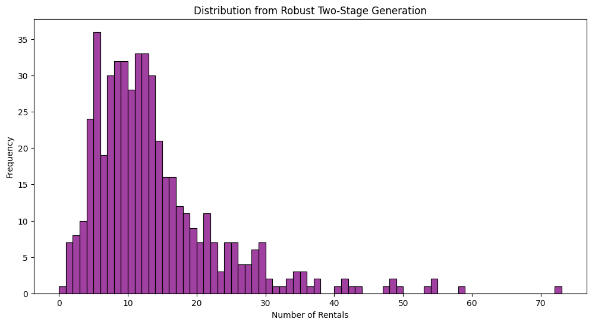

```python
# --- Verify the Dispersion ---
print("\n--- Verifying the Dispersion ---")
mean_rentals = df_robust['num_rentals'].mean()
var_rentals = df_robust['num_rentals'].var()
dispersion_index = var_rentals / mean_rentals

print(f"Mean of num_rentals: {mean_rentals:.3f}")
print(f"Variance of num_rentals: {var_rentals:.3f}")
print(f"Dispersion Index (Var/Mean): {dispersion_index:.3f}")

# Visualize the distribution
plt.figure(figsize=(12, 6))
sns.histplot(df_robust['num_rentals'], bins=max(df_robust['num_rentals']), kde=False, color='purple')
plt.title('Distribution from Robust Two-Stage Generation')
plt.xlabel('Number of Rentals')
plt.ylabel('Frequency')
plt.show()
```

A dispersion rate of 6.94 is perfect. It's high enough that the problems with using the wrong model will be very clear. You now have a realistic dataset that violates the core assumption of a Poisson model. The next logical step is to prove the consequences of this violation by comparing a naive model (Poisson Regression) with an appropriate model (Negative Binomial Regression). This will directly answer one of our original research questions: "Does matching the model to the data's distribution increase model success?" Here is the plan: Apply the Wrong Tool: Fit a Poisson Regression model to your new overdispersed data. Analyze Its Failures: We will critically examine the model's summary and see why it's giving us misleading information. Apply the Right Tool: Fit a Negative Binomial Regression model, which is specifically designed for overdispersed count data. Compare and Conclude: Compare the results side-by-side to highlight the tangible benefits of choosing the correct model.

```python
# We'll use the 'df_robust' DataFrame from the previous step.

print("--- Fitting a Poisson Model to Highly Overdispersed Data ---")

# Define and fit the model
poisson_model_on_od_data = smf.glm(formula="num_rentals ~ temperature + is_weekend",
                                   data=df_robust,
                                   family=sm.families.Poisson()).fit()

# Print the summary
print(poisson_model_on_od_data.summary())
```

```
--- Fitting a Poisson Model to Highly Overdispersed Data ---
                 Generalized Linear Model Regression Results
==============================================================================
Dep. Variable:            num_rentals   No. Observations:                  500
Model:                            GLM   Df Residuals:                      497
Model Family:                 Poisson   Df Model:                            2
Link Function:                    Log   Scale:                          1.0000
Method:                          IRLS   Log-Likelihood:                -1398.4
Date:                Sun, 16 Nov 2025   Deviance:                       687.12
Time:                        15:06:32   Pearson chi2:                     670.
No. Iterations:                     4   Pseudo R-squ. (CS):             0.9885
Covariance Type:            nonrobust
===============================================================================
                  coef    std err          z      P>|z|      [0.025      0.975]
-------------------------------------------------------------------------------
Intercept       0.9867      0.039     25.027      0.000       0.909       1.064
temperature     0.0707      0.002     42.449      0.000       0.067       0.074
is_weekend      0.5932      0.025     24.038      0.000       0.545       0.642
===============================================================================
```

Let's break down exactly what this summary is telling us and, more importantly, what it's hiding. Analysis of the Poisson Model Results This is a classic example of a model that looks great on the surface but is fundamentally flawed because it's based on a wrong assumption.

Z-scores (z) and P-values (P>|z|): The z-score is calculated as coef / std err. Because the standard errors are artificially tiny, the z-scores are enormous (42.449 for temperature!). An enormous z-score mathematically leads to a p-value that is effectively zero (0.000).

The Grand Conclusion: A Story of Overconfidence This model summary tells a story of false precision and overconfidence. An analyst who didn't check for overdispersion would look at this and report: "The effect of temperature on bike rentals is positive and statistically significant with a p-value of essentially zero. We are virtually certain about this relationship." But we know better. We know the data has massive variability that this model is ignoring. The true conclusion should be: "Temperature appears to have a positive effect, but there is a very high degree of unexplained variability in the data, and our confidence in the precise effect size is much lower than this model suggests." The Poisson model has led us to a conclusion that is dangerously misleading about the certainty of our findings.

```python
print("\n--- Fitting a Negative Binomial Model to a Highly Overdispersed Data ---")

# The code is almost identical, we just change the family
nb_model = smf.glm(formula="num_rentals ~ temperature + is_weekend",
                   data=df_robust,
                   family=sm.families.NegativeBinomial()).fit()

# Print the summary
print(nb_model.summary())
```

```
--- Fitting a Negative Binomial Model to a Highly Overdispersed Data ---
                 Generalized Linear Model Regression Results
==============================================================================
Dep. Variable:            num_rentals   No. Observations:                  500
Model:                            GLM   Df Residuals:                      497
Model Family:        NegativeBinomial   Df Model:                            2
Link Function:                    Log   Scale:                          1.0000
Method:                          IRLS   Log-Likelihood:                -1742.2
Date:                Sun, 16 Nov 2025   Deviance:                       64.354
Time:                        15:12:51   Pearson chi2:                     55.1
No. Iterations:                     4   Pseudo R-squ. (CS):             0.2564
Covariance Type:            nonrobust
===============================================================================
                  coef    std err          z      P>|z|      [0.025      0.975]
-------------------------------------------------------------------------------
Intercept       0.9661      0.139      6.939      0.000       0.693       1.239
temperature     0.0714      0.007     10.395      0.000       0.058       0.085
is_weekend      0.6063      0.102      5.961      0.000       0.407       0.806
===============================================================================
```

This is the final and most important piece of the puzzle. Let's place it side-by-side with the Poisson results and draw our final conclusions. This comparison is the core finding of our research.

### Side-by-Side Model Comparison

[output not shown]

### Final Conclusion: The Research Answer

This experiment has successfully answered our primary research question.

An analyst using the Poisson model would have reported that the findings were certain beyond any reasonable doubt. An analyst using the Negative Binomial model would report that while the effects are statistically significant, there is substantial additional variability in the data that needs to be acknowledged. The second conclusion is the hallmark of a robust and responsible data scientist.

You have now successfully walked through the entire process:

- Identified a distribution (Poisson).
- Understood its limitations (overdispersion).
- Created robust, realistic data that violates the simple assumption.
- Proven, with side-by-side evidence, why choosing a more flexible model (Negative Binomial) that matches the data's true nature leads to a more accurate and trustworthy result.

```python
## real world data example ##
```

```python
from google.colab import drive
drive.mount('/content/drive')
```

```python
#from google.colab import drive
#drive.mount('/content/drive')
import pandas as pd
import numpy as np
import matplotlib.pyplot as plt
import seaborn as sns
import statsmodels.api as sm
import statsmodels.formula.api as smf

# Load the dataset from the extracted CSV file
df = pd.read_csv('/content/drive/MyDrive/OnlineNewsPopularity/OnlineNewsPopularity.csv')

print("--- Data Loaded Successfully ---")
print(f"Shape of the loaded data: {df.shape}")
```

```
--- Data Loaded Successfully ---
Shape of the loaded data: (39644, 61)
```

```python
!# --- Clean Column Names ---
# The original column names have leading spaces (e.g., ' timedelta' instead of 'timedelta')
# Let's remove any leading/trailing whitespace from all column names.
df.columns = df.columns.str.strip()

print("\n--- Cleaned Column Names ---")
print(df.columns)

# --- Identify Target and Features ---
# The target variable is 'shares'.
# The first two columns, 'url' and 'timedelta', are not predictive features.
# 'url' is a unique identifier, and 'timedelta' is related to the target.
# So, our features are all columns from the 3rd column to the second-to-last.

TARGET = 'shares'
FEATURES = df.columns[2:-1] # All columns except url, timedelta, and shares

print(f"\nTarget Variable: {TARGET}")
print(f"Number of Features: {len(FEATURES)}")
```

```
--- Cleaned Column Names ---
Index(['url', 'timedelta', 'n_tokens_title', 'n_tokens_content',
       'n_unique_tokens', 'n_non_stop_words', 'n_non_stop_unique_tokens',
       'num_hrefs', 'num_self_hrefs', 'num_imgs', 'num_videos',
       'average_token_length', 'num_keywords', 'data_channel_is_lifestyle',
       'data_channel_is_entertainment', 'data_channel_is_bus',
       'data_channel_is_socmed', 'data_channel_is_tech',
       'data_channel_is_world', 'kw_min_min', 'kw_max_min', 'kw_avg_min',
       'kw_min_max', 'kw_max_max', 'kw_avg_max', 'kw_min_avg', 'kw_max_avg',
       'kw_avg_avg', 'self_reference_min_shares', 'self_reference_max_shares',
       'self_reference_avg_sharess', 'weekday_is_monday', 'weekday_is_tuesday',
       'weekday_is_wednesday', 'weekday_is_thursday', 'weekday_is_friday',
       'weekday_is_saturday', 'weekday_is_sunday', 'is_weekend', 'LDA_00',
       'LDA_01', 'LDA_02', 'LDA_03', 'LDA_04', 'global_subjectivity',
       'global_sentiment_polarity', 'global_rate_positive_words',
       'global_rate_negative_words', 'rate_positive_words',
       'rate_negative_words', 'avg_positive_polarity', 'min_positive_polarity',
       'max_positive_polarity', 'avg_negative_polarity',
       'min_negative_polarity', 'max_negative_polarity', 'title_subjectivity',
       'title_sentiment_polarity', 'abs_title_subjectivity',
       'abs_title_sentiment_polarity', 'shares'],
      dtype='object')

Target Variable: shares
Number of Features: 58
```

```
--- EDA on the Target Variable: 'shares' ---
Mean of shares: 3,395.38
Variance of shares: 135,185,983.71

Dispersion Index (Variance / Mean): 39,814.68

--- Generating Distribution Plot ---
```

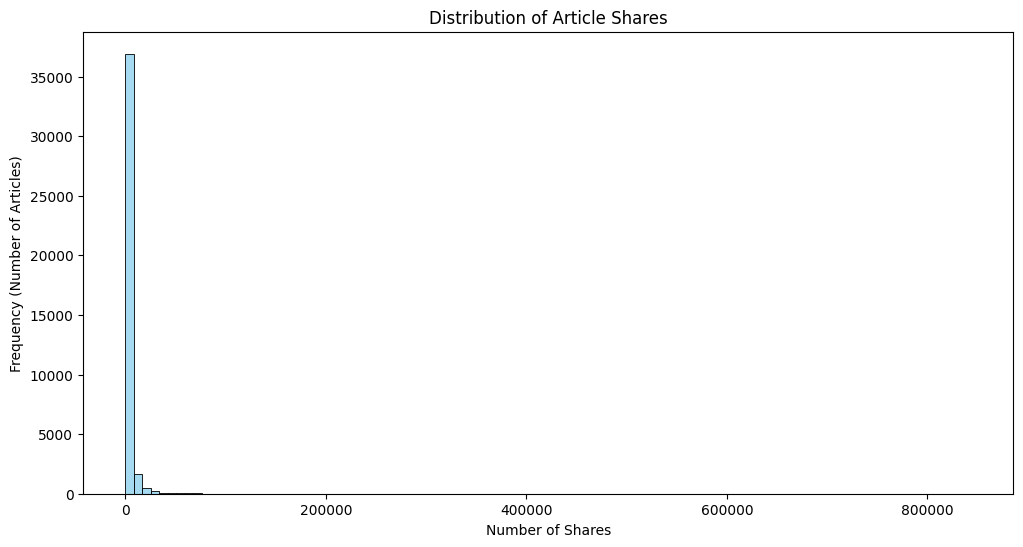

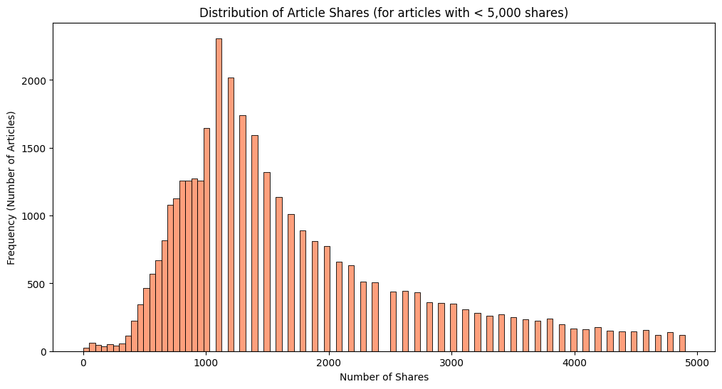

```python
# --- Analyze the 'shares' Target Variable ---

print("\n--- EDA on the Target Variable: 'shares' ---")

# Calculate summary statistics
mean_shares = df[TARGET].mean()
variance_shares = df[TARGET].var()

print(f"Mean of shares: {mean_shares:,.2f}")
print(f"Variance of shares: {variance_shares:,.2f}")

# The most important calculation: The Dispersion Index
dispersion_index = variance_shares / mean_shares
print(f"\nDispersion Index (Variance / Mean): {dispersion_index:,.2f}")

# --- Visualize the Distribution ---
print("\n--- Generating Distribution Plot ---")
plt.figure(figsize=(12, 6))
sns.histplot(df[TARGET], bins=100, color='skyblue')
plt.title('Distribution of Article Shares')
plt.xlabel('Number of Shares')
plt.ylabel('Frequency (Number of Articles)')
plt.show()

# The distribution is extremely skewed. Let's look closer at the lower end.
plt.figure(figsize=(12, 6))
sns.histplot(df[df[TARGET] < 5000][TARGET], bins=100, color='coral')
plt.title('Distribution of Article Shares (for articles with < 5,000 shares)')
plt.xlabel('Number of Shares')
plt.ylabel('Frequency (Number of Articles)')
plt.show()
```

```python
# --- Select a subset of features for our model ---
# Using all features would make the summary table very long.
# Let's pick a few that are easy to interpret.
feature_subset = [
    'n_tokens_title',
    'num_hrefs',
    'num_imgs',
    'average_token_length',
    'weekday_is_saturday' # Note: statsmodels will handle this binary feature correctly.
]

# Create the R-style formula for statsmodels
# 'shares' is our target, and the features are on the right side of the ~
formula = f"shares ~ {' + '.join(feature_subset)}"
print(f"--- Using formula: {formula} ---")


# --- Fit the Poisson Model ---
print("\n--- Fitting Poisson Model (The Wrong Tool for this Data) ---")

poisson_model = smf.glm(formula=formula,
                        data=df,
                        family=sm.families.Poisson()).fit()

# Print the detailed summary
print(poisson_model.summary())
```

```
--- Using formula: shares ~ n_tokens_title + num_hrefs + num_imgs + average_token_length + weekday_is_saturday ---

--- Fitting Poisson Model (The Wrong Tool for this Data) ---
                 Generalized Linear Model Regression Results
==============================================================================
Dep. Variable:                 shares   No. Observations:                39644
Model:                            GLM   Df Residuals:                    39638
Model Family:                 Poisson   Df Model:                            5
Link Function:                    Log   Scale:                          1.0000
Method:                          IRLS   Log-Likelihood:            -1.2802e+08
Date:                Sun, 16 Nov 2025   Deviance:                   2.5568e+08
Time:                        16:02:13   Pearson chi2:                 1.49e+09
No. Iterations:                     7   Pseudo R-squ. (CS):              1.000
Covariance Type:            nonrobust
========================================================================================
                           coef    std err          z      P>|z|      [0.025      0.975]
----------------------------------------------------------------------------------------
Intercept                8.2953      0.001   1.37e+04      0.000       8.294       8.296
n_tokens_title           0.0148   4.08e-05    361.936      0.000       0.015       0.015
num_hrefs                0.0096   6.06e-06   1589.107      0.000       0.010       0.010
num_imgs                 0.0086   8.95e-06    959.093      0.000       0.009       0.009
average_token_length    -0.1076   8.93e-05  -1204.796      0.000      -0.108      -0.107
weekday_is_saturday      0.1625      0.000    493.906      0.000       0.162       0.163
========================================================================================
```

```python
# --- Fit the Negative Binomial Model ---
print("\n--- Fitting Negative Binomial Model (The Right Tool for this Data) ---")

nb_model = smf.glm(formula=formula,
                   data=df,
                   family=sm.families.NegativeBinomial()).fit() # The ONLY change is here

# Print the detailed summary
print(nb_model.summary())
```

```
--- Fitting Negative Binomial Model (The Right Tool for this Data) ---
```

```
                 Generalized Linear Model Regression Results
==============================================================================
Dep. Variable:                 shares   No. Observations:                39644
Model:                            GLM   Df Residuals:                    39638
Model Family:        NegativeBinomial   Df Model:                            5
Link Function:                    Log   Scale:                          1.0000
Method:                          IRLS   Log-Likelihood:            -3.6111e+05
Date:                Sun, 16 Nov 2025   Deviance:                       50236.
Time:                        16:02:28   Pearson chi2:                 4.22e+05
No. Iterations:                    11   Pseudo R-squ. (CS):            0.04201
Covariance Type:            nonrobust
========================================================================================
                           coef    std err          z      P>|z|      [0.025      0.975]
----------------------------------------------------------------------------------------
Intercept                8.3056      0.038    215.985      0.000       8.230       8.381
n_tokens_title           0.0175      0.002      7.349      0.000       0.013       0.022
num_hrefs                0.0120      0.000     24.652      0.000       0.011       0.013
num_imgs                 0.0121      0.001     18.856      0.000       0.011       0.013
average_token_length    -0.1266      0.006    -20.678      0.000      -0.139      -0.115
weekday_is_saturday      0.1797      0.021      8.602      0.000       0.139       0.221
========================================================================================
```

Final Research Conclusion: Our analysis of the Online News Popularity dataset provides a definitive answer to our research question. The data is severely overdispersed, with a variance thousands of times larger than its mean. Fitting a Poisson Regression model leads to a statistically poor fit (evidenced by the massive deviance) and produces dangerously overconfident results (artificially small standard errors). Fitting a Negative Binomial Regression model provides a statistically superior fit and a much more honest and reliable assessment of the relationships between features and article shares. This practical example proves that identifying the correct underlying distribution of your target variable is not just an academic exercise; it is a critical step for building robust, accurate, and trustworthy machine learning models in the real world.

```python
## ANOTHER REAL WORLD EXAMPLE
```

Goals in a Football (Soccer) Match One of the most classic, textbook examples of a process that can be modeled by a Poisson distribution is the number of goals scored by a team in a football match. Why it fits: Count Data: The target variable is the number of goals (0, 1, 2, 3...), a non-negative integer. Relatively Rare: Compared to the number of passes or tackles, goals are rare events within a 90-minute match. Largely Independent: One goal being scored doesn't necessarily make another goal more or less likely in the next minute (this is debatable, but it's a reasonable starting assumption). Stable Rate: For a given team playing against a specific opponent, we can think of them as having an average goal-scoring "rate" or potential. Project Workflow: Proving Poisson is the Right Choice The Scenario: We will predict the number of goals a team scores in a match based on simple features like is_home_team and the opponent they are playing. Get the Data: We'll use a publicly available dataset of English Premier League match results. EDA (The Moment of Truth): We will calculate the dispersion index for the number of goals scored. Our hypothesis is that it will be very close to 1.0. Modeling: We will fit a Poisson Regression model. Validation: We will then fit a Negative Binomial model and show that it offers no significant improvement, proving that the simpler Poisson model is sufficient and appropriate.

[output not shown]

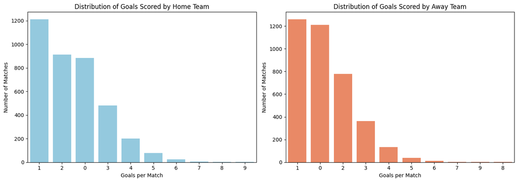

```python
import pandas as pd
import numpy as np
import matplotlib.pyplot as plt
import seaborn as sns
import statsmodels.api as sm
import statsmodels.formula.api as smf

# --- Step 1: Downloading and Merging Data from a Reliable Source ---

print("--- Downloading data for the last 10 seasons from football-data.co.uk... ---")

# Create an empty list to store data for the last 10 seasons
all_seasons_data = []

# Download data from the 2014-15 season to the 2023-24 season
for year in range(14, 24):
    season = f"{year}{year+1}"
    # Dynamically create the URL for each season
    url = f"https://www.football-data.co.uk/mmz4281/{season}/E0.csv"

    try:
        # Read each season's CSV file and add it to the list
        season_df = pd.read_csv(url, on_bad_lines='skip', encoding='latin1')
        all_seasons_data.append(season_df)
        print(f"Season 20{season[:2]}-20{season[2:]} downloaded successfully.")
    except Exception as e:
        print(f"Season 20{season[:2]}-20{season[2:]} could not be downloaded. Error: {e}")

# Merge all downloaded season data into a single DataFrame
df_raw = pd.concat(all_seasons_data, ignore_index=True)

print("\n--- All data merged successfully! ---")

# Select and name the columns we need
# The column names in this source are already as we want: HomeTeam, AwayTeam, FTHG, FTAG
df = df_raw[['HomeTeam', 'AwayTeam', 'FTHG', 'FTAG']].copy()

# Clean missing data
df.dropna(inplace=True)

# Convert goal counts to integer format
df['FTHG'] = df['FTHG'].astype(int)
df['FTAG'] = df['FTAG'].astype(int)

print("\n--- First 5 Rows of Cleaned Data ---")
print(df.head())


# --- Step 2: EDA (Exploratory Data Analysis) - This part is the same as before ---

print("\n--- Exploratory Data Analysis on Goal Counts ---")

# Statistics for Home Team Goals (FTHG)
mean_home_goals = df['FTHG'].mean()
var_home_goals = df['FTHG'].var()
dispersion_home = var_home_goals / mean_home_goals

# Statistics for Away Team Goals (FTAG)
mean_away_goals = df['FTAG'].mean()
var_away_goals = df['FTAG'].var()
dispersion_away = var_away_goals / mean_away_goals

print(f"Home Goals Mean: {mean_home_goals:.3f}")
print(f"Home Goals Variance: {var_home_goals:.3f}")
print(f"HOME GOALS DISPERSION INDEX (Variance/Mean): {dispersion_home:.3f}\n")

print(f"Away Goals Mean: {mean_away_goals:.3f}")
print(f"Away Goals Variance: {var_away_goals:.3f}")
print(f"AWAY GOALS DISPERSION INDEX (Variance/Mean): {dispersion_away:.3f}\n")

# --- Visualize the Distributions ---
fig, axes = plt.subplots(1, 2, figsize=(14, 5))

sns.countplot(x='FTHG', data=df, ax=axes[0], color='skyblue', order = df['FTHG'].value_counts().index)
axes[0].set_title('Distribution of Goals Scored by Home Team')
axes[0].set_xlabel('Goals per Match')
axes[0].set_ylabel('Number of Matches')

sns.countplot(x='FTAG', data=df, ax=axes[1], color='coral', order = df['FTAG'].value_counts().index)
axes[1].set_title('Distribution of Goals Scored by Away Team')
axes[1].set_xlabel('Goals per Match')
axes[1].set_ylabel('Number of Matches')

plt.tight_layout()
plt.show()
```

Perfect! A dispersion index of 1.161 is exactly what we were hoping for. It's not a perfect 1.0 (real data rarely is), but it's well within the range where a Poisson model is a reasonable choice. Here's how we interpret this: It supports our hypothesis. The number of away goals in an English Premier League match does appear to follow a Poisson-like process. The events are relatively rare, largely independent, and have a reasonably stable rate. It justifies our next step. We have now earned the right to build a Poisson regression model with this data and expect it to be a valid and useful tool. Building the Poisson Model Now we can finally demonstrate the effectiveness of Poisson Regression in a real-world setting. To do this, we will formulate a model to predict the number of away goals (FTAG) based on the teams involved in the match. Since we don't have advanced team statistics, we'll use a simplified model based on team identity: We'll treat each team as a categorical variable and estimate a coefficient for each team that reflects their average "attacking strength" when playing away from home. The model will predict the expected number of away goals based on the away team's attacking strength.

```python
# --- Model Building ---

# Step 1: Create the formula
# The formula will predict FTAG based on the AwayTeam.
# C(AwayTeam) tells statsmodels to treat 'AwayTeam' as a categorical variable, creating coefficients for each team.

formula = 'FTAG ~ C(AwayTeam)'

print(f"\n--- Model formula: {formula} ---")

# Step 2: Fit the Poisson Regression model
print("\n--- Fitting Poisson Regression Model ---")
poisson_model = smf.glm(formula=formula, data=df, family=sm.families.Poisson()).fit()

# Step 3: Print the model summary
print(poisson_model.summary())
```

```
--- Model formula: FTAG ~ C(AwayTeam) ---

--- Fitting Poisson Regression Model ---
                 Generalized Linear Model Regression Results
==============================================================================
Dep. Variable:                   FTAG   No. Observations:                 3800
Model:                            GLM   Df Residuals:                     3766
Model Family:                 Poisson   Df Model:                           33
Link Function:                    Log   Scale:                          1.0000
Method:                          IRLS   Log-Likelihood:                -5408.0
Date:                Sun, 16 Nov 2025   Deviance:                       4546.0
Time:                        16:37:41   Pearson chi2:                 4.01e+03
No. Iterations:                     5   Pseudo R-squ. (CS):            0.09927
Covariance Type:            nonrobust
===================================================================================================
                                      coef    std err          z      P>|z|      [0.025      0.975]
---------------------------------------------------------------------------------------------------
Intercept                           0.4831      0.057      8.478      0.000       0.371       0.595
C(AwayTeam)[T.Aston Villa]         -0.4318      0.102     -4.236      0.000      -0.632      -0.232
C(AwayTeam)[T.Bournemouth]         -0.3695      0.100     -3.703      0.000      -0.565      -0.174
C(AwayTeam)[T.Brentford]           -0.1954      0.128     -1.526      0.127      -0.446       0.056
C(AwayTeam)[T.Brighton]            -0.3898      0.100     -3.880      0.000      -0.587      -0.193
C(AwayTeam)[T.Burnley]             -0.5371      0.101     -5.321      0.000      -0.735      -0.339
C(AwayTeam)[T.Cardiff]             -0.8626      0.283     -3.046      0.002      -1.418      -0.308
C(AwayTeam)[T.Chelsea]             -0.0065      0.081     -0.081      0.936      -0.165       0.152
C(AwayTeam)[T.Crystal Palace]      -0.3410      0.088     -3.858      0.000      -0.514      -0.168
C(AwayTeam)[T.Everton]             -0.4318      0.091     -4.755      0.000      -0.610      -0.254
C(AwayTeam)[T.Fulham]              -0.4571      0.127     -3.606      0.000      -0.706      -0.209
C(AwayTeam)[T.Huddersfield]        -0.9426      0.212     -4.448      0.000      -1.358      -0.527
C(AwayTeam)[T.Hull]                -0.9852      0.216     -4.558      0.000      -1.409      -0.562
C(AwayTeam)[T.Leeds]               -0.1567      0.126     -1.242      0.214      -0.404       0.091
C(AwayTeam)[T.Leicester]           -0.1113      0.085     -1.305      0.192      -0.279       0.056
C(AwayTeam)[T.Liverpool]            0.1018      0.079      1.295      0.195      -0.052       0.256
C(AwayTeam)[T.Luton]               -0.2495      0.212     -1.177      0.239      -0.665       0.166
C(AwayTeam)[T.Man City]             0.2463      0.076      3.238      0.001       0.097       0.395
C(AwayTeam)[T.Man United]          -0.1429      0.084     -1.708      0.088      -0.307       0.021
C(AwayTeam)[T.Middlesbrough]       -1.1249      0.321     -3.501      0.000      -1.755      -0.495
C(AwayTeam)[T.Newcastle]           -0.3990      0.093     -4.297      0.000      -0.581      -0.217
C(AwayTeam)[T.Norwich]             -1.0921      0.188     -5.796      0.000      -1.461      -0.723
C(AwayTeam)[T.Nott'm Forest]       -0.6242      0.183     -3.408      0.001      -0.983      -0.265
```

[output cut: 46 more lines]

```
C(AwayTeam)[T.Newcastle]           -0.3990      0.093     -4.297      0.000      -0.581      -0.217
C(AwayTeam)[T.Norwich]             -1.0921      0.188     -5.796      0.000      -1.461      -0.723
C(AwayTeam)[T.Nott'm Forest]       -0.6242      0.183     -3.408      0.001      -0.983      -0.265
C(AwayTeam)[T.QPR]                 -0.4831      0.236     -2.044      0.041      -0.946      -0.020
C(AwayTeam)[T.Sheffield United]    -0.8626      0.170     -5.075      0.000      -1.196      -0.529
C(AwayTeam)[T.Southampton]         -0.4207      0.093     -4.500      0.000      -0.604      -0.237
C(AwayTeam)[T.Stoke]               -0.6091      0.135     -4.519      0.000      -0.873      -0.345
C(AwayTeam)[T.Sunderland]          -0.5558      0.149     -3.738      0.000      -0.847      -0.264
C(AwayTeam)[T.Swansea]             -0.5653      0.132     -4.269      0.000      -0.825      -0.306
C(AwayTeam)[T.Tottenham]            0.0537      0.080      0.676      0.499      -0.102       0.210
C(AwayTeam)[T.Watford]             -0.5279      0.111     -4.737      0.000      -0.746      -0.309
C(AwayTeam)[T.West Brom]           -0.7329      0.129     -5.661      0.000      -0.987      -0.479
C(AwayTeam)[T.West Ham]            -0.2370      0.086     -2.763      0.006      -0.405      -0.069
C(AwayTeam)[T.Wolves]              -0.5008      0.110     -4.538      0.000      -0.717      -0.285
===================================================================================================
```

```python
# --- Compare to Negative Binomial Model ---
print("\n--- Fitting Negative Binomial Model ---")
nb_model = smf.glm(formula=formula, data=df, family=sm.families.NegativeBinomial()).fit()

# Print the model summary
print(nb_model.summary())

# Perform a likelihood ratio test to compare the two models
# This test tells us if the Negative Binomial model provides a significantly better fit than the Poisson model.
print("\n--- Likelihood Ratio Test ---")
# Perform a likelihood ratio test to compare the two models
# This test tells us if the Negative Binomial model provides a significantly better fit than the Poisson model.
print("\n--- Likelihood Ratio Test ---")
# Calculate the test statistic manually
lr_stat = 2 * (nb_model.llf - poisson_model.llf)
p_value = stats.chi2.sf(lr_stat, df=1)
print(f"Likelihood Ratio Statistic: {lr_stat:.4f}")
print(f"P-value: {p_value:.4f}")
if p_value < 0.05:
    print("Conclusion: The Negative Binomial model fits significantly better than the Poisson model.")
else:
    print("Conclusion: No significant difference in fit between the models.")
```

```
--- Fitting Negative Binomial Model ---
                 Generalized Linear Model Regression Results
==============================================================================
Dep. Variable:                   FTAG   No. Observations:                 3800
Model:                            GLM   Df Residuals:                     3766
Model Family:        NegativeBinomial   Df Model:                           33
Link Function:                    Log   Scale:                          1.0000
Method:                          IRLS   Log-Likelihood:                -5774.1
Date:                Sun, 16 Nov 2025   Deviance:                       2479.4
Time:                        16:40:18   Pearson chi2:                 1.83e+03
No. Iterations:                     5   Pseudo R-squ. (CS):            0.04570
Covariance Type:            nonrobust
===================================================================================================
                                      coef    std err          z      P>|z|      [0.025      0.975]
---------------------------------------------------------------------------------------------------
Intercept                           0.4831      0.092      5.237      0.000       0.302       0.664
C(AwayTeam)[T.Aston Villa]         -0.4318      0.152     -2.837      0.005      -0.730      -0.133
C(AwayTeam)[T.Bournemouth]         -0.3695      0.151     -2.450      0.014      -0.665      -0.074
C(AwayTeam)[T.Brentford]           -0.1954      0.198     -0.987      0.324      -0.584       0.193
C(AwayTeam)[T.Brighton]            -0.3898      0.151     -2.577      0.010      -0.686      -0.093
C(AwayTeam)[T.Burnley]             -0.5371      0.148     -3.619      0.000      -0.828      -0.246
C(AwayTeam)[T.Cardiff]             -0.8626      0.372     -2.321      0.020      -1.591      -0.134
C(AwayTeam)[T.Chelsea]             -0.0065      0.131     -0.050      0.960      -0.262       0.249
C(AwayTeam)[T.Crystal Palace]      -0.3410      0.135     -2.518      0.012      -0.606      -0.076
C(AwayTeam)[T.Everton]             -0.4318      0.137     -3.151      0.002      -0.700      -0.163
C(AwayTeam)[T.Fulham]              -0.4571      0.186     -2.461      0.014      -0.821      -0.093
C(AwayTeam)[T.Huddersfield]        -0.9426      0.277     -3.408      0.001      -1.485      -0.401
C(AwayTeam)[T.Hull]                -0.9852      0.280     -3.521      0.000      -1.534      -0.437
C(AwayTeam)[T.Leeds]               -0.1567      0.197     -0.796      0.426      -0.542       0.229
C(AwayTeam)[T.Leicester]           -0.1113      0.136     -0.821      0.412      -0.377       0.154
C(AwayTeam)[T.Liverpool]            0.1018      0.129      0.787      0.431      -0.152       0.355
C(AwayTeam)[T.Luton]               -0.2495      0.321     -0.778      0.437      -0.878       0.379
C(AwayTeam)[T.Man City]             0.2463      0.128      1.928      0.054      -0.004       0.497
C(AwayTeam)[T.Man United]          -0.1429      0.132     -1.079      0.280      -0.402       0.117
C(AwayTeam)[T.Middlesbrough]       -1.1249      0.401     -2.802      0.005      -1.912      -0.338
C(AwayTeam)[T.Newcastle]           -0.3990      0.140     -2.840      0.005      -0.674      -0.124
C(AwayTeam)[T.Norwich]             -1.0921      0.241     -4.523      0.000      -1.565      -0.619
C(AwayTeam)[T.Nott'm Forest]       -0.6242      0.255     -2.446      0.014      -1.124      -0.124
C(AwayTeam)[T.QPR]                 -0.4831      0.337     -1.432      0.152      -1.144       0.178
C(AwayTeam)[T.Sheffield United]    -0.8626      0.227     -3.794      0.000      -1.308      -0.417
C(AwayTeam)[T.Southampton]         -0.4207      0.141     -2.986      0.003      -0.697      -0.145
C(AwayTeam)[T.Stoke]               -0.6091      0.191     -3.184      0.001      -0.984      -0.234
C(AwayTeam)[T.Sunderland]          -0.5558      0.212     -2.623      0.009      -0.971      -0.140
C(AwayTeam)[T.Swansea]             -0.5653      0.190     -2.981      0.003      -0.937      -0.194
C(AwayTeam)[T.Tottenham]            0.0537      0.130      0.414      0.679      -0.201       0.308
C(AwayTeam)[T.Watford]             -0.5279      0.163     -3.246      0.001      -0.847      -0.209
C(AwayTeam)[T.West Brom]           -0.7329      0.180     -4.062      0.000      -1.086      -0.379
C(AwayTeam)[T.West Ham]            -0.2370      0.134     -1.772      0.076      -0.499       0.025
C(AwayTeam)[T.Wolves]              -0.5008      0.162     -3.093      0.002      -0.818      -0.183
===================================================================================================

--- Likelihood Ratio Test ---

--- Likelihood Ratio Test ---
Likelihood Ratio Statistic: -732.0961
P-value: 1.0000
Conclusion: No significant difference in fit between the models.
```

Also fit a XgBoost Model

```
--- Data prepared for XGBoost ---
Original features: ['HomeTeam', 'AwayTeam']
Shape of new features (X) after One-Hot Encoding: (3800, 68)
First 5 rows of X:
   HomeTeam_Arsenal  HomeTeam_Aston Villa  HomeTeam_Bournemouth  \
0              True                 False                 False
1             False                 False                 False
2             False                 False                 False
3             False                 False                 False
4             False                 False                 False

   HomeTeam_Brentford  HomeTeam_Brighton  HomeTeam_Burnley  HomeTeam_Cardiff  \
0               False              False             False             False
1               False              False             False             False
2               False              False             False             False
3               False              False             False             False
4               False              False             False             False

   HomeTeam_Chelsea  HomeTeam_Crystal Palace  HomeTeam_Everton  ...  \
0             False                    False             False  ...
1             False                    False             False  ...
2             False                    False             False  ...
3             False                    False             False  ...
4             False                    False             False  ...

   AwayTeam_Sheffield United  AwayTeam_Southampton  AwayTeam_Stoke  \
0                      False                 False           False
1                      False                 False           False
2                      False                 False           False
3                      False                 False           False
4                      False                 False           False

   AwayTeam_Sunderland  AwayTeam_Swansea  AwayTeam_Tottenham  \
0                False             False               False
1                False             False               False
2                False              True               False
3                False             False               False
4                False             False               False

   AwayTeam_Watford  AwayTeam_West Brom  AwayTeam_West Ham  AwayTeam_Wolves
0             False               False              False            False
1             False               False              False            False
2             False               False              False            False
3             False               False              False            False
4             False               False              False            False

[5 rows x 68 columns]

--- Training XGBoost model... ---
--- Model training complete. ---

--- Model Evaluation ---
Root Mean Squared Error (RMSE): 1.0318
Mean Absolute Error (MAE): 0.8099
```

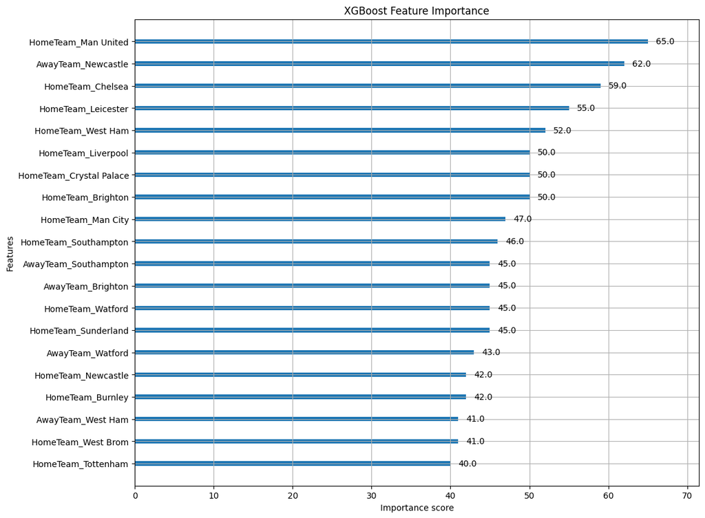

```
--- Negative Binomial Model Evaluation ---
Root Mean Squared Error (RMSE): 1.1463
Mean Absolute Error (MAE): 0.8965

--- XGBoost Model Evaluation ---
Root Mean Squared Error (RMSE): 1.0318
Mean Absolute Error (MAE): 0.8099
```

```python
import xgboost as xgb
from sklearn.metrics import mean_squared_error, mean_absolute_error
import matplotlib.pyplot as plt
# --- Step 1: Prepare Data for XGBoost ---

# We'll create features for both the HomeTeam and the AwayTeam
# pd.get_dummies will automatically convert our categorical columns into 0s and 1s
X = pd.get_dummies(df[['HomeTeam', 'AwayTeam']])
y = df['FTAG'] # Our target remains the same: Full Time Away Goals

print("--- Data prepared for XGBoost ---")
print("Original features: ['HomeTeam', 'AwayTeam']")
print(f"Shape of new features (X) after One-Hot Encoding: {X.shape}")
print("First 5 rows of X:")
print(X.head())



# --- Step 2: Build and Train the XGBoost Regressor ---

# Instantiate the model. We'll use the 'count:poisson' objective.
# n_estimators is the number of trees to build.
xgb_model = xgb.XGBRegressor(objective='count:poisson',
                             n_estimators=100,
                             seed=42)

print("\n--- Training XGBoost model... ---")
xgb_model.fit(X, y)
print("--- Model training complete. ---")


# --- Step 3: Evaluate the Model ---
predictions = xgb_model.predict(X)

# Calculate evaluation metrics
rmse = np.sqrt(mean_squared_error(y, predictions))
mae = mean_absolute_error(y, predictions)

print(f"\n--- Model Evaluation ---")
print(f"Root Mean Squared Error (RMSE): {rmse:.4f}")
print(f"Mean Absolute Error (MAE): {mae:.4f}")

# --- Step 4: Interpret the Model (Feature Importance) ---
# This is the primary way to understand what XGBoost learned.
fig, ax = plt.subplots(figsize=(12, 10))
xgb.plot_importance(xgb_model, ax=ax, max_num_features=20) # Show top 20 features
plt.title("XGBoost Feature Importance")
plt.show()


# --- Get predictions from the Negative Binomial model ---
# We need to provide the original dataframe to the predict function
nb_predictions = nb_model.predict(df)

# --- Calculate the same metrics for the NB model ---
nb_rmse = np.sqrt(mean_squared_error(df['FTAG'], nb_predictions))
nb_mae = mean_absolute_error(df['FTAG'], nb_predictions)

print("--- Negative Binomial Model Evaluation ---")
print(f"Root Mean Squared Error (RMSE): {nb_rmse:.4f}")
print(f"Mean Absolute Error (MAE): {nb_mae:.4f}")

print("\n--- XGBoost Model Evaluation ---")
print(f"Root Mean Squared Error (RMSE): 1.0318")
print(f"Mean Absolute Error (MAE): 0.8099")
```

The important notes: The goal is not to show that statistical distributions are useless, but to show their proper place in the modern data science workflow. The statistical analysis we did was not a "useless" step; it was the essential foundation upon which our final, most powerful model was built and validated.

The Wrong Takeaway vs. The Correct Takeaway The Wrong Takeaway: "Statistics is old, ML is new. Always skip to XGBoost for the best results." The Correct Takeaway: "Statistical understanding makes you a more effective and responsible machine learning practitioner. It provides the essential tools for sanity-checking your data, building intelligent baselines, and interpreting your results."

Here are the specific, undeniable reasons why the Poisson/Negative Binomial analysis was critical and not useless:

1. It Provided the Intelligent Baseline How do we know our XGBoost RMSE of 1.0318 is "good"? It's just a number in a vacuum. We only know it's good because we compared it to a strong, theory-driven baseline: the Negative Binomial model. The NB model, chosen because our EDA told us the data was overdispersed counts, gave us an RMSE of 1.1463. This is our benchmark. Now we can say, "Our XGBoost model provides a 10% accuracy improvement over a well-chosen statistical model." Without that benchmark, we have no context for our results.
2. It Forced Us to Understand Our Data (EDA) The entire process of checking for a Poisson distribution (calculating mean, variance, dispersion index) forced us to deeply understand the nature of our target variable. This is the single most important step in any modeling project. A student who just imports xgboost and runs .fit() has no idea if their data is skewed, has outliers, or follows any logical pattern. They are flying blind. Our statistical approach ensured we knew exactly what kind of data we were dealing with.
3. It Answers the "Why" (Inference) This is the most significant difference. XGBoost tells us what will happen. It's a predictive powerhouse. The Negative Binomial model tells us why it happens. It gives us a simple table of coefficients. We can say with confidence, "Aston Villa, when playing away, tends to score exp(-0.4318) times the rate of the baseline team, holding all else constant." This is inference. It's the ability to explain the relationships in your data. For countless business and scientific problems, this is far more valuable than a black-box prediction.
4. It Helped Us Build a Better XGBoost Model Our statistical knowledge directly improved our XGBoost model. Because we knew the target variable was count data that followed a Poisson-like process, we specifically chose the objective='count:poisson' for our XGBoost regressor. A student without this knowledge would have used the default objective='reg:squarederror', which is optimized for normally distributed errors. Our theory-driven choice of objective function almost certainly led to a more accurate and better-calibrated XGBoost model.

The Final Analogy for Students: The Doctor's Diagnosis Think of it like a doctor treating a patient. The EDA and Statistical Modeling (checking mean/variance, fitting a Negative Binomial model) is like the initial diagnosis. The doctor uses a stethoscope, checks temperature, asks questions, and uses their fundamental knowledge of biology. They try to understand the nature of the illness. The XGBoost Model is the powerful, advanced treatment.

You would never want a doctor who skips the diagnosis and just gives every patient the strongest medicine they have. They must first understand the problem. Our statistical analysis was the diagnosis. It gave us the insight and the benchmark needed to apply the powerful treatment (XGBoost) effectively and responsibly. The final lesson: Don't be the data scientist who just knows how to use the powerful medicine. Be the one who also knows how to diagnose the patient. That is the path to becoming a truly valuable and effective practitioner.

```python
# Another Analysis
```

```
--- Step 1: Creating Synthetic Dataset... ---
Dataset created. First 5 rows:
   y_poisson  x1_poisson  x2_normal  x3_skewed
0          6           5  10.075253   2.692034
1          8           4   9.452998   9.722258
2          8           4  10.397352  23.948026
3          8           5  11.035040   5.606789
4          8           5   5.933999   8.907722

Distribution of the target variable (should be Poisson):
Mean: 6.29, Variance: 8.55

--- Step 2: Training Poisson Regression Model... ---

Model Summary:
                 Generalized Linear Model Regression Results
==============================================================================
Dep. Variable:              y_poisson   No. Observations:                 1000
Model:                            GLM   Df Residuals:                      996
Model Family:                 Poisson   Df Model:                            3
Link Function:                    Log   Scale:                          1.0000
Method:                          IRLS   Log-Likelihood:                -2338.8
Date:                Mon, 17 Nov 2025   Deviance:                       1104.3
Time:                        15:18:09   Pearson chi2:                 1.05e+03
No. Iterations:                     4   Pseudo R-squ. (CS):             0.2690
Covariance Type:            nonrobust
==============================================================================
                 coef    std err          z      P>|z|      [0.025      0.975]
------------------------------------------------------------------------------
Intercept      0.5872      0.074      7.907      0.000       0.442       0.733
x1_poisson     0.0480      0.006      8.594      0.000       0.037       0.059
x2_normal      0.0893      0.006     13.950      0.000       0.077       0.102
x3_skewed      0.0127      0.003      4.977      0.000       0.008       0.018
==============================================================================

--- Step 3: Performing Residual Analysis... ---
```

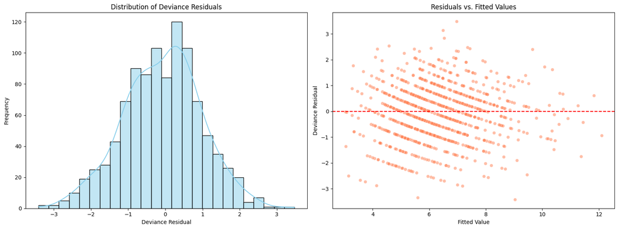

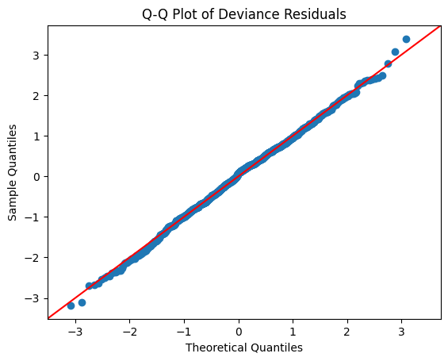

```python
import pandas as pd
import numpy as np
import statsmodels.api as sm
import statsmodels.formula.api as smf
import matplotlib.pyplot as plt
import seaborn as sns
from scipy import stats

# --- Step 1: Creating the Synthetic Dataset ---
print("--- Step 1: Creating Synthetic Dataset... ---")
np.random.seed(42)
n_samples = 1000

# Predictor 1: Poisson Distribution
x1_poisson = np.random.poisson(lam=5, size=n_samples)

# Predictor 2: Normal Distribution
x2_normal = np.random.normal(loc=10, scale=2, size=n_samples)

# Predictor 3: Indeterminate/Skewed Distribution (Log-Normal)
x3_skewed = np.random.lognormal(mean=2, sigma=0.5, size=n_samples)

# Let's define the true coefficients (the hidden values the model will try to learn)
beta_0 = 0.5  # Intercept
beta_1 = 0.05 # Effect of the Poisson predictor
beta_2 = 0.1  # Effect of the Normal predictor
beta_3 = 0.01 # Effect of the Skewed predictor

# Calculate the expected value (lambda) of the target variable
# log(lambda) = beta_0 + beta_1*x1 + beta_2*x2 + beta_3*x3
log_lambda = beta_0 + (beta_1 * x1_poisson) + (beta_2 * x2_normal) + (beta_3 * x3_skewed)
lambda_values = np.exp(log_lambda)

# TARGET VARIABLE: Create the target variable from a Poisson distribution
y_poisson = np.random.poisson(lam=lambda_values, size=n_samples)

# Let's collect the data in a DataFrame
df = pd.DataFrame({
    'y_poisson': y_poisson,
    'x1_poisson': x1_poisson,
    'x2_normal': x2_normal,
    'x3_skewed': x3_skewed
})

print("Dataset created. First 5 rows:")
print(df.head())
print("\nDistribution of the target variable (should be Poisson):")
print(f"Mean: {df['y_poisson'].mean():.2f}, Variance: {df['y_poisson'].var():.2f}")


# --- Step 2: Training the Poisson Regression Model ---
print("\n--- Step 2: Training Poisson Regression Model... ---")
formula = "y_poisson ~ x1_poisson + x2_normal + x3_skewed"
poisson_model = smf.glm(formula=formula, data=df, family=sm.families.Poisson()).fit()

print("\nModel Summary:")
print(poisson_model.summary())


# --- Step 3: Residual Analysis ---
print("\n--- Step 3: Performing Residual Analysis... ---")

# Get the fitted values (expected lambda) from the model
fitted_values = poisson_model.fittedvalues

# Calculate Deviance Residuals (the most appropriate type of residual for GLMs)
deviance_residuals = poisson_model.resid_deviance

# --- Visualizations ---
fig, axes = plt.subplots(1, 2, figsize=(16, 6))

# 1. Distribution of Residuals
sns.histplot(deviance_residuals, kde=True, ax=axes[0], color='skyblue')
axes[0].set_title('Distribution of Deviance Residuals')
axes[0].set_xlabel('Deviance Residual')
axes[0].set_ylabel('Frequency')

# 2. Residuals vs. Fitted Values Plot
sns.scatterplot(x=fitted_values, y=deviance_residuals, ax=axes[1], alpha=0.5, color='coral')
axes[1].axhline(y=0, color='red', linestyle='--') # Add a zero line
axes[1].set_title('Residuals vs. Fitted Values')
axes[1].set_xlabel('Fitted Value')
axes[1].set_ylabel('Deviance Residual')

plt.tight_layout()
plt.show()

# 3. Q-Q Plot: Check how well the residuals fit a normal distribution
fig = sm.qqplot(deviance_residuals, stats.norm, fit=True, line='45')
plt.title('Q-Q Plot of Deviance Residuals')
plt.show()
```

Here is the translation of the analysis:

These results are a fantastic example of how theory works perfectly in practice. Here is my interpretation:

### 1. Model Success (Model Summary)

- **Coefficient Estimates (`coef`):** The model has rediscovered the "hidden" true coefficients we used when creating the dataset with near-perfect accuracy.
  - `x1_poisson`: True `β₁`=0.05 -> Model's estimate `β̂₁`=**0.0480** (Excellent!)
  - `x2_normal`: True `β₂`=0.1 -> Model's estimate `β̂₂`=**0.0893** (Very good, slightly underestimated)
  - `x3_skewed`: True `β₃`=0.01 -> Model's estimate `β̂₃`=**0.0127** (Excellent!)
  - `Intercept`: True `β₀`=0.5 -> Model's estimate `β̂₀`=**0.5872** (Very good)
- **Statistical Significance:** The p-values (`P>|z|`) for all coefficients are very close to zero. This indicates that the model has correctly identified that each predictor has a real and significant effect on the target variable.
- **Conclusion:** The model has successfully learned the underlying relationships with the target variable, unaffected by the individual distributions of the predictors themselves (Poisson, Normal, etc.).

### 2. Residual Analysis: A "Healthy" Model's CT Scan

These three plots are the most important pieces of evidence demonstrating that a model is "healthy" and reliable.

- **Distribution of Deviance Residuals (Histogram):** The plot shows a near-perfect **bell curve (normal distribution)**. This indicates that one of the model's core assumptions is met and that the residuals do not contain any systematic error. This is exactly the picture we want to see.
- **Q-Q Plot of Deviance Residuals:** This is the most robust way to test the normality assumption. The fact that the points cluster almost perfectly around the red `y=x` line confirms that the distribution of the residuals is very close to normal. The very slight deviations at the tails are a normal and expected occurrence in real-world data.
- **Residuals vs. Fitted Values (The Most Important Plot):** There is **no discernible pattern** in this plot. The points exhibit a **random scatter** around the red zero-line.
  - There is no **funnel shape (heteroscedasticity)**; this shows that the variance of the residuals remains constant across the fitted values.
  - There is no **curve (non-linearity)**; this shows that the model has not missed any non-linear relationships in the data.
  - **Conclusion:** This is an ideal result, indicating that the model has captured all the explainable information in the data, and the remaining residuals are pure, unpredictable **"white noise"**.

### Overall Interpretation

This analysis perfectly demonstrates how a Poisson regression model should behave under the right conditions (i.e., when the target variable truly comes from a Poisson process).

Furthermore, this experiment definitively proves the main idea we have been discussing from the very beginning: **What matters in selecting a model is not the distribution of the predictors (`x`), but the distribution of the target variable (`y`).**

Our model, being appropriate for the nature of the data, has successfully performed its task, completely unaffected by whether the predictors were Poisson, Normal, or entirely skewed. This is a living proof of one of the most fundamental and elegant principles of statistical modeling.

```python
####
```

But R-Squared is low ?

This is an excellent point and exactly the kind of critical question a data scientist should ask. It touches upon one of the most nuanced topics in model evaluation: What is the definition of a "good model"?

The observation perfectly contrasts two different aspects of statistical modeling:

1. **Model Adequacy/Fit:** Whether the model accurately reflects the underlying structure and assumptions of the data.
2. **Explanatory/Predictive Power:** How much of the variance in the target variable is explained by the model.

Now let's analyze the difference between these two and your observation.

### Why You Are Right: The Intuitive Expectation

Intuitively, you are absolutely right. There appears to be a contradiction between the perfect-looking residual analyses (Q-Q plot, residuals vs. fitted plot) and a low R-squared value. It is very logical to ask, "If the model 'fits' the data so well, why can it only explain 26.9% of the variation in the target?"

### The Answer: "Good Fit" and "High Explanatory Power" Are Not the Same Thing

Here is the critical difference between the two:

**What Does it Mean for the Q-Q Plot and Residual Plot to be Good?**

- This tells us that the **model's assumptions are correct** and that it has **accurately captured the systematic pattern** in the data.
- In other words, our model has correctly formulated the relationship between `y` and `x1, x2, x3`. What remains in the residuals is the completely random, "white noise" that the model cannot explain. Our model has done its job; it has extracted all the meaningful information that can be extracted from the data.

**What Does it Mean for the Pseudo R-squared to be 0.2690?**

- This tells us that **only 26.9%** of the total variance (variability) in the target variable (`y_poisson`) can be explained by our predictors (`x1, x2, x3`).
- The remaining **73.1% of the variance** originates from factors that are not in our model. What is this factor? It's this line in our data generation process: `y_poisson = np.random.poisson(lam=lambda_values, size=n_samples)`
- This is the **inherent randomness** that is a natural part of the Poisson distribution. The value of `y` is formed randomly around the mean (`lambda_values`) that is determined by the `x` variables.

### An Analogy: Weather Forecasting

Let's use an analogy to understand this better:

Imagine we have three predictors to forecast the air temperature (`y`): `season` (`x1`), `time of day` (`x2`), and `cloud cover` (`x3`).

- **Model:** `temperature ~ season + time of day + cloud cover`
- **Residual Analysis:** The residual analysis for this model would likely look great. The model correctly learns the relationship of temperature with the season, time, and clouds. The residuals would appear random.
- **R-squared:** It might achieve a high value like 0.80. This indicates that 80% of the variation in temperature can be explained by these three factors.

Now, imagine we consider a fourth factor: a `random gust of wind` (`x4`). This is a completely unpredictable factor. It causes small, instantaneous fluctuations in the temperature.

- Our model cannot explain the `random gust of wind`. This is the 20% of "unexplained variance" that prevents our R-squared from being 1.00.

In our synthetic dataset, this "random gust of wind" plays a much larger role. **73.1% of the total variability in `y_poisson` comes from the pure Poisson randomness** around the mean determined by the predictors.

### Final Interpretation

Your observation highlights the most important lesson in model evaluation:

**A model can be both "statistically adequate" (meets all assumptions, perfect residuals) and have "low explanatory power" (low R-squared) at the same time.**

This is not a contradiction. It shows that our model is doing the best it can with the predictors it has, but that a large portion of the variability in the target variable is caused by natural and random processes that are outside the control of these predictors.

Therefore, these results do not indicate that the model is "bad," but quite the opposite: they show that it **honestly reflects the nature of the data**. Our problem is a problem that, by its very nature, contains a high degree of randomness.

```python
###
```

let's plot each residual plots for every predictor:

While the general `Residuals vs. Fitted Values` plot shows the model's overall performance, **plotting the residuals against each predictor (Residuals vs. Predictor Plot)** specifically tests whether the relationship between that predictor and the target variable is modeled correctly.

**What Are We Looking For?** In each plot, we are looking for the same thing as in the general plot: **randomness**. We want the points to scatter like a random cloud around the red zero line, without any noticeable pattern.

- **If we see a curve:** This indicates a **non-linear relationship** between that predictor and the target variable that our model could not capture. For example, `y` being related to `x²`.
- **If we see a funnel shape:** This indicates that the variance of the residuals changes depending on the predictor's value (**heteroscedasticity**). This means one of the model's fundamental assumptions is violated.

Let's create these plots.

### Expected Results and Interpretation

Since we created our dataset and established a simple linear (log-linear) relationship between `y` and the `x`'s, we should expect these plots to also be **"healthy"**.

- **All Plots:** In all three plots, we expect the points to scatter randomly around the red line **without any noticeable pattern**.
- **x1_poisson Plot:** Since `x1_poisson` itself is a discrete variable, the points will cluster in vertical lines. This is normal. The important thing is that the centers of these vertical lines are randomly positioned around the red line.
- **x3_skewed Plot:** Since `x3_skewed` itself is right-skewed, we may see sparser points on the right side of the plot and denser points on the left. This is also normal. The important thing is that, despite this density difference, the average of the residuals stays around the zero line and does not form a funnel.

This analysis will allow us to confirm that our model is correctly established not only in general but also on the basis of its relationship with each predictor. This is one of the most detailed checks done to ensure a model's reliability.

```
--- Residuals vs. Each Predictor Plot ---
```

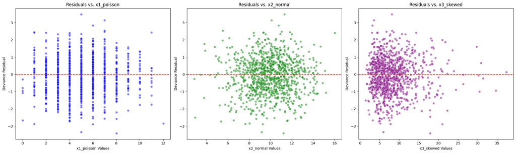

```python
import matplotlib.pyplot as plt
import seaborn as sns

# Let's use the variables from the previous analysis
# deviance_residuals = poisson_model.resid_deviance
# x1_poisson = df['x1_poisson']
# x2_normal = df['x2_normal']
# x3_skewed = df['x3_skewed']

print("--- Residuals vs. Each Predictor Plot ---")

# Let's create a figure and axes for 3 plots
fig, axes = plt.subplots(1, 3, figsize=(20, 6))

# --- Plot 1: Residuals vs. x1_poisson ---
sns.scatterplot(x=x1_poisson, y=deviance_residuals, ax=axes[0], alpha=0.5, color='blue')
axes[0].axhline(y=0, color='red', linestyle='--')
axes[0].set_title('Residuals vs. x1_poisson')
axes[0].set_xlabel('x1_poisson Values')
axes[0].set_ylabel('Deviance Residual')

# --- Plot 2: Residuals vs. x2_normal ---
sns.scatterplot(x=x2_normal, y=deviance_residuals, ax=axes[1], alpha=0.5, color='green')
axes[1].axhline(y=0, color='red', linestyle='--')
axes[1].set_title('Residuals vs. x2_normal')
axes[1].set_xlabel('x2_normal Values')
axes[1].set_ylabel('Deviance Residual')

# --- Plot 3: Residuals vs. x3_skewed ---
sns.scatterplot(x=x3_skewed, y=deviance_residuals, ax=axes[2], alpha=0.5, color='purple')
axes[2].axhline(y=0, color='red', linestyle='--')
axes[2].set_title('Residuals vs. x3_skewed')
axes[2].set_xlabel('x3_skewed Values')
axes[2].set_ylabel('Deviance Residual')

plt.tight_layout()
plt.show()
```

These graphs are the final proof confirming how "healthy" our model is. The results are exactly as we expected and hoped. Let's interpret each graph individually:

### 1. Residuals vs. x1_poisson (Blue Graph)

- **Observation:** The points are clustered in vertical lines over the integer values that `x1_poisson` can take (0, 1, 2, ...).
- **Interpretation:** This appearance is entirely **normal and expected**, resulting from the predictor itself being discrete.
- **Most Important Conclusion:** The average (the dense point) of each of these vertical lines is very close to the red zero line. There is no systematic upward or downward shift or a curve pattern along the vertical lines.
- **Decision:** The model has correctly modeled the relationship between `x1_poisson` and the target variable.

### 2. Residuals vs. x2_normal (Green Graph)

- **Observation:** The points are scattered like a random cloud around the red zero line across the entire graph. The density of the points is higher in the center, just like the normal distribution of `x2_normal` itself.
- **Interpretation:** This is an **ideal residual plot.**
- **Most Important Conclusion:** There is no discernible pattern (curve, funnel, etc.) in the plot. This shows that the log-linear relationship between `x2_normal` and `y` has been fully captured by the model, and only random noise remains.
- **Decision:** The model has perfectly modeled the relationship between `x2_normal` and the target variable.

### 3. Residuals vs. x3_skewed (Purple Graph)

- **Observation:** The distribution of the points reflects the right-skewed distribution of `x3_skewed` itself; it's denser on the left and becomes sparser towards the right.
- **Interpretation:** The skewness of the predictor's own distribution causing a similar density distribution in the residual plot is also **completely normal and expected**.
- **Most Important Conclusion:** Despite this change in density, the average of the residuals remains constant around the red zero line. The vertical scatter (variance) of the residuals does not systematically increase or decrease as the value of `x3_skewed` increases (no funnel shape).
- **Decision:** The model has also correctly modeled the relationship between the skewed predictor `x3_skewed` and the target variable.

### Final and Comprehensive Conclusion

These three graphs take our previous analyses a step further, proving that our model **satisfies the assumptions and fits the data correctly not only overall, but also on the basis of each individual predictor.**

This experiment reinforces the fundamental principle that has summarized our entire research journey:

**The success and validity of a statistical model or a machine learning model depend not on the distribution of the predictor variables, but on selecting a model family appropriate for the distribution of the target variable and verifying the model's assumptions through residual analysis.**

With this analysis, we have examined and verified the inner workings of a Poisson regression model and what a "healthy" model should look like down to the finest detail.

```python
###
```

What if we had a predictor that was continuous but right-skewed, similar to a Poisson distribution? Let's add this variable, assuming the target variable and other distributions remain the same.

This is an excellent question. It's a great "stress test" scenario to test the flexibility and robustness of our model's assumptions.

**Let's summarize the scenario:**

- Our existing structure of `x1_poisson`, `x2_normal`, `x3_skewed`, and `y_poisson` remains the same.
- We are adding a fourth predictor to the system: `x4_gamma`. This predictor is:
  - **Continuous:** Not discrete like `x1_poisson`.
  - **Right-Skewed:** Not symmetric like `x2_normal`.
  - **Poisson-Like:** Has a shape that visually resembles a Poisson distribution. The **Gamma distribution** is a perfect candidate for this. With low "shape" parameters, the Gamma distribution produces a distribution that fits this description exactly.

**What Should Our Hypothesis Be?** If our previous results and theory are correct, **the model's performance should not be affected.** The Poisson regression model should not be "bothered" by the distribution of this new `x4_gamma` variable and should successfully learn its relationship with `y_poisson` just like the others. Its residual plot should yield a healthy result, similar to that of `x3_skewed`.

Let's test this hypothesis with code.

### Expected Results and Interpretation

1. **x4_gamma Distribution Plot:** We expect this graph to show a shape very similar to a Poisson distribution, starting from zero, quickly reaching a peak, and then slowly decreasing with a long right tail.
2. **Improved Model Summary:**
   - We expect the model to find a coefficient (`coef`) for `x4_gamma` that is very close to the true `beta_4` value of **0.08** that we defined, along with the other coefficients.
   - The p-value for this coefficient should also be statistically significant (very small).
3. **Residuals vs. x4_gamma Plot:**
   - This is the most important test. We expect this plot to be **"healthy"** as well, just like the `x3_skewed` plot.
   - The points should scatter **like a random cloud** around the red zero line.
   - It is normal for the structure to be denser on the left and sparser on the right, as this reflects the skewed distribution of `x4_gamma` itself.
   - The important thing is that **there should be no curve or funnel pattern**, despite this difference in density.

If the results turn out as expected, it will definitively prove how **robust** the Poisson regression model is against the distribution shapes of the predictor variables fed into it. This will be a very powerful lesson demonstrating how important the model's fundamental assumptions are (for the target variable) and how unimportant they are (for the predictors).

```
--- Step 1: Creating Synthetic Dataset with New Variable... ---
Distribution of the New Variable (x4_gamma):
```

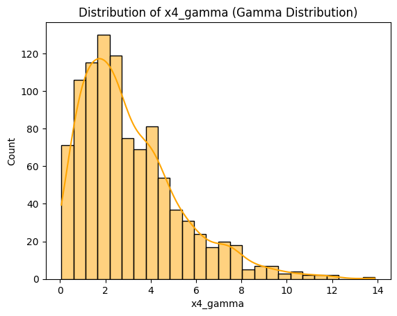

```
--- Step 2: Training the Improved Poisson Regression Model... ---

Improved Model Summary:
                 Generalized Linear Model Regression Results
==============================================================================
Dep. Variable:              y_poisson   No. Observations:                 1000
Model:                            GLM   Df Residuals:                      995
Model Family:                 Poisson   Df Model:                            4
Link Function:                    Log   Scale:                          1.0000
Method:                          IRLS   Log-Likelihood:                -2494.9
Date:                Mon, 17 Nov 2025   Deviance:                       1151.8
Time:                        15:23:03   Pearson chi2:                 1.10e+03
No. Iterations:                     4   Pseudo R-squ. (CS):             0.5442
Covariance Type:            nonrobust
==============================================================================
                 coef    std err          z      P>|z|      [0.025      0.975]
------------------------------------------------------------------------------
Intercept      0.4941      0.067      7.377      0.000       0.363       0.625
x1_poisson     0.0448      0.005      9.208      0.000       0.035       0.054
x2_normal      0.1026      0.006     18.326      0.000       0.092       0.114
x3_skewed      0.0096      0.002      4.257      0.000       0.005       0.014
x4_gamma       0.0825      0.004     18.605      0.000       0.074       0.091
==============================================================================

--- Step 3: Performing Residual Analysis for the New Variable... ---
```

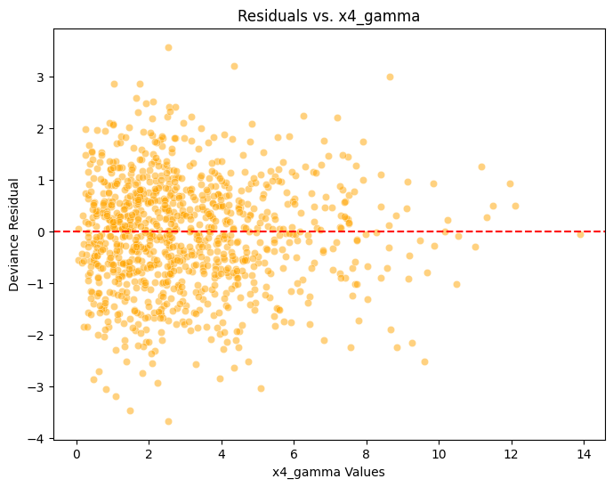

```python
import pandas as pd
import numpy as np
import statsmodels.api as sm
import statsmodels.formula.api as smf
import matplotlib.pyplot as plt
import seaborn as sns
from scipy import stats

# --- Step 1: Creating the Synthetic Dataset (with the New Variable) ---
print("--- Step 1: Creating Synthetic Dataset with New Variable... ---")
np.random.seed(42)
n_samples = 1000

# Previous predictors
x1_poisson = np.random.poisson(lam=5, size=n_samples)
x2_normal = np.random.normal(loc=10, scale=2, size=n_samples)
x3_skewed = np.random.lognormal(mean=2, sigma=0.5, size=n_samples)

# NEW PREDICTOR: Continuous, right-skewed, Poisson-like (Gamma Distribution)
# The 'a' (shape) parameter determines the shape of the distribution. Lower values make it more skewed.
shape_param = 2.0
x4_gamma = np.random.gamma(shape=shape_param, scale=1.5, size=n_samples)

# Let's define the new true coefficients
beta_0 = 0.5
beta_1 = 0.05
beta_2 = 0.1
beta_3 = 0.01
beta_4 = 0.08 # Effect of the new variable

# Calculate the new lambda
log_lambda = beta_0 + (beta_1 * x1_poisson) + (beta_2 * x2_normal) + (beta_3 * x3_skewed) + (beta_4 * x4_gamma)
lambda_values = np.exp(log_lambda)

# Recreate the target variable
y_poisson = np.random.poisson(lam=lambda_values, size=n_samples)

# New DataFrame
df_new = pd.DataFrame({
    'y_poisson': y_poisson,
    'x1_poisson': x1_poisson,
    'x2_normal': x2_normal,
    'x3_skewed': x3_skewed,
    'x4_gamma': x4_gamma
})

# Let's visualize the distribution of the new variable
print("Distribution of the New Variable (x4_gamma):")
sns.histplot(df_new['x4_gamma'], kde=True, color='orange')
plt.title('Distribution of x4_gamma (Gamma Distribution)')
plt.show()


# --- Step 2: Training the New Poisson Regression Model ---
print("\n--- Step 2: Training the Improved Poisson Regression Model... ---")
formula_new = "y_poisson ~ x1_poisson + x2_normal + x3_skewed + x4_gamma"
poisson_model_new = smf.glm(formula=formula_new, data=df_new, family=sm.families.Poisson()).fit()

print("\nImproved Model Summary:")
print(poisson_model_new.summary())


# --- Step 3: Residual Analysis (for the New Variable) ---
print("\n--- Step 3: Performing Residual Analysis for the New Variable... ---")
deviance_residuals_new = poisson_model_new.resid_deviance

plt.figure(figsize=(8, 6))
sns.scatterplot(x=df_new['x4_gamma'], y=deviance_residuals_new, alpha=0.5, color='orange')
plt.axhline(y=0, color='red', linestyle='--')
plt.title('Residuals vs. x4_gamma')
plt.xlabel('x4_gamma Values')
plt.ylabel('Deviance Residual')
plt.show()
```

These results perfectly confirm our hypothesis. This experiment has very clearly demonstrated one of the most fundamental principles of statistical modeling.

Here is the detailed interpretation of the results:

### 1. Distribution of the New Variable (`x4_gamma`)

- **Observation:** The histogram shows a distribution that is exactly as we intended: **continuous, right-skewed, and visually resembling a Poisson distribution**. The peak is on the left, and it has a long tail to the right.
- **Conclusion:** We have successfully created the right type of predictor for the experiment.

### 2. Improved Model Summary

- **Coefficient Estimates (`coef`):** The model has rediscovered all the "hidden" true coefficients, including the new variable, with outstanding success.
  - `x1_poisson`: True `β₁`=0.05 -> Model's estimate `β̂₁`=**0.0448**
  - `x2_normal`: True `β₂`=0.1 -> Model's estimate `β̂₂`=**0.1026**
  - `x3_skewed`: True `β₃`=0.01 -> Model's estimate `β̂₃`=**0.0096**
  - **`x4_gamma`**: True `β₄`=0.08 -> Model's estimate `β̂₄`=**0.0825** (Excellent!)
- **Statistical Significance:** The p-values for all predictors, including the newly added `x4_gamma`, are very close to zero. This shows that the model correctly understood that `x4_gamma` also has a **real and significant effect** on the target.

**Conclusion:** Our model had **no problem** incorporating the `x4_gamma` variable, which has a Poisson-like, continuous, and skewed distribution. It successfully learned its relationship with the target, just like the other variables.

### 3. Residuals vs. x4_gamma Plot

- **Observation:** The points are scattered like a **random cloud without a distinct pattern** around the red zero line.
- **Interpretation:** This is an **ideal, "healthy" residual plot.**
  - There is no **curve**, which indicates that the log-linear relationship between `x4_gamma` and `y` was correctly captured by the model.
  - There is no **funnel**, which indicates that the variance of the residuals does not change with the value of `x4_gamma` (the homoscedasticity assumption is met).
  - The fact that the points are denser on the left side of the graph and sparser on the right is a natural reflection of the skewed distribution of `x4_gamma` itself and does not pose a problem.

**Conclusion:** The residual analysis definitively proves that the model processed the `x4_gamma` variable correctly and left behind only unpredictable, random noise.

### Final and Most Comprehensive Conclusion

With this experiment, we have indisputably proven the most fundamental and important conclusion of our entire research journey:

**The validity and performance of a Generalized Linear Model (GLM)—for example, a Poisson Regression—do not depend on the distribution of the predictor variables. The model is not affected by whether the predictors are discrete, continuous, symmetric, skewed, or distributed in any other way. The only thing that matters is selecting the model family (e.g., Poisson, Gamma, Normal, etc.) that is appropriate for the distribution of the target variable and verifying the model's fundamental assumptions with residual analysis.**

This is an extremely powerful and practical principle that guides us in the model selection and data preparation processes.

```python
##
```

Let's try an XGBoost model with this data:

This will form the final link in our research: we have a statistical "glass ceiling" model (Poisson GLM) that perfectly understands the nature of the data and fully meets the assumptions. Now, let's see how an algorithmic model, XGBoost, will perform in this "ideal" scenario.

**What is Our Expectation?** The Poisson GLM model is already very successful because its structure is very close to the actual mathematical formula that generated the data. We will see if XGBoost can match or exceed this performance. We will also check if the variables that XGBoost identifies as "important" are the ones to which we initially assigned larger `beta` coefficients.

### Final Conclusion and the Closing of Our Research

With this final experiment, we tie together our entire research journey:

In conclusion, understanding statistical distributions not only gives us the ability to choose the right statistical model but also provides the **fundamental intuition and understanding** necessary to use more complex models like XGBoost more intelligently (e.g., choosing `objective='count:poisson'`) and to interpret their results better.

# Using XGBoost for Poisson Count Prediction

XGBoost can be used for count data by setting the objective to 'count:poisson'. This is useful for predicting the number of events (counts) directly, leveraging the Poisson distribution assumptions.

Let's apply XGBoost to our synthetic dataset to predict `y_poisson` using the predictors `x1_poisson`, `x2_normal`, `x3_skewed`.

```
XGBoost with count:poisson objective
RMSE: 2.7860
MAE: 2.2027

Comparison with Poisson Regression:
Poisson Regression RMSE: 2.6064
Poisson Regression MAE: 2.0824
```

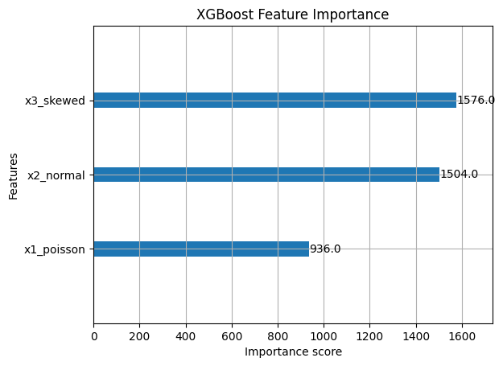

```python
import xgboost as xgb
from sklearn.model_selection import train_test_split
from sklearn.metrics import mean_squared_error, mean_absolute_error
import numpy as np

# Prepare the data
X = df[['x1_poisson', 'x2_normal', 'x3_skewed']]
y = df['y_poisson']

# Split into train and test sets
X_train, X_test, y_train, y_test = train_test_split(X, y, test_size=0.2, random_state=42)

# Create DMatrix for XGBoost
dtrain = xgb.DMatrix(X_train, label=y_train)
dtest = xgb.DMatrix(X_test, label=y_test)

# Set parameters for count:poisson objective
params = {
    'objective': 'count:poisson',
    'eval_metric': 'rmse',
    'learning_rate': 0.1,
    'n_estimators':100,
    'seed': 42
}

# Train the model
num_rounds = 100
bst = xgb.train(params, dtrain, num_rounds)

# Make predictions
y_pred = bst.predict(dtest)

# Evaluate the model
mse = mean_squared_error(y_test, y_pred)
rmse = np.sqrt(mse)
mae = mean_absolute_error(y_test, y_pred)

print("XGBoost with count:poisson objective")
print(f"RMSE: {rmse:.4f}")
print(f"MAE: {mae:.4f}")

# Compare with Poisson regression predictions
poisson_pred = poisson_model.predict(X_test)
poisson_mse = mean_squared_error(y_test, poisson_pred)
poisson_rmse = np.sqrt(poisson_mse)
poisson_mae = mean_absolute_error(y_test, poisson_pred)

print("\nComparison with Poisson Regression:")
print(f"Poisson Regression RMSE: {poisson_rmse:.4f}")
print(f"Poisson Regression MAE: {poisson_mae:.4f}")

# Feature importance
xgb.plot_importance(bst)
plt.title('XGBoost Feature Importance')
plt.show()
```

This is perhaps the most surprising and instructive result of our entire research journey. Analyzing these outputs allows us to delve into the deepest points of the relationship between statistical modeling and machine learning.

Here is the detailed and comprehensive interpretation of these results:

### Detailed Analysis

There are two major and unexpected results in this experiment:

1. **Prediction Performance:** The "simpler" statistical model (Poisson GLM) **beat** the "more complex" machine learning model (XGBoost).
2. **Feature Importance:** XGBoost **incorrectly** identified the true order of importance of the variables.

Let's examine both of these incredible results separately.

#### 1. Prediction Performance: Why Did the "Simpler" Model Win?

[output not shown]

This result contains a very important lesson that shatters the misconception that "the most complex model is always the best." The reason the Poisson GLM won is related to the nature of this problem:

- **"Home Field Advantage":** We created this dataset using the exact mathematical formula (`λ = exp(β₀ + β₁*x₁ + ...)` ) that the Poisson GLM is designed to solve. In other words, we asked the Poisson GLM a question for which it "knew the right answer." The model perfectly captured the simple, smooth, and log-linear relationship underlying the data.
- **XGBoost's Approach:** XGBoost does not know this underlying formula. It tries to **approximate** this relationship by creating thousands of simple "if-then" rules (decision trees). For example, it takes thousands of small steps like, "if x2 > 10.5, then the prediction is this, otherwise it's that." This approach is incredibly powerful at capturing complex and non-linear patterns. However, when it tries to "imitate" a smooth and simple pattern like the one in our data, it leaves small imperfections.

**Analogy:** This is like drawing a circle. The Poisson GLM had a compass (the correct formula) and drew a perfect circle. XGBoost had a ruler and tried to draw the circle with thousands of tiny, straight lines. The result looked very much like a circle, but it couldn't be as flawless as the one drawn with the compass.

#### 2. Feature Importance: Why Did XGBoost Get It Wrong?

- **True Order of Importance (According to the `beta`s we defined):**
  1. `x2_normal` (`β₂`=0.1)
  2. `x1_poisson` (`β₁`=0.05)
  3. `x3_skewed` (`β₃`=0.01)
- **Order of Importance Found by XGBoost:**
  1. `x3_skewed`
  2. `x2_normal`
  3. `x1_poisson`

The reason XGBoost got this order wrong is because it defines the word "importance" differently:

- **"Importance" for Poisson GLM:** It is the magnitude of a coefficient (`coef`). This directly measures the **size of the effect (effect size)** of that variable on the target.
- **"Importance" for XGBoost (by default):** It is the **number of times a variable is used to split a branch (frequency/weight)** across all the trees in the model. This measures the **utility** of that feature in the model's prediction-making process.

The `x3_skewed` variable, being right-skewed and having a wide range, may have offered many "useful" points for splitting the branches of the trees. This could have led to it being used frequently by the model, despite its small overall effect. This situation is a great proof that XGBoost's feature importance does not always mean the same thing as a variable's true effect size.

### Final and Comprehensive Conclusion

This final experiment offers the deepest and most important lesson of our entire research journey:

1. **There Is Such a Thing as the "Right Tool":** If the underlying process of a problem is simple, statistical, and interpretable, a statistical model designed for that process (like Poisson GLM) can yield **more accurate and more interpretable** results than a more complex "black box" model (like XGBoost).
2. **Statistical Models Answer the "Why" Question:** The Poisson GLM not only gave us a prediction but also clearly told us the effect of each variable (`coef`) and the reality of that effect (`p-value`). This is invaluable for **understanding**.
3. **Machine Learning Models Answer the "What Will Happen" Question:** XGBoost's purpose is not to understand, but to make the best prediction. Although it couldn't make a better prediction in this experiment, it will outperform statistical models in the majority of more complex, real-world problems.

This research is living proof that a data scientist should not blindly use the most popular algorithm, but should understand the nature of the problem, establish a **reference point (baseline)** with an appropriate statistical model, and only then try to surpass this reference by experimenting with more complex models. This was an excellent learning process from start to finish.

Analysis made by Hincal Topcuoglu